# Keller-BrandDeletionCompetition-2025-SSRN.pdf

Converted from PDF `Keller-BrandDeletionCompetition-2025-SSRN.pdf` · 78 pages · anchors: page `#pN`, block `#pN-bK`

Page 1

#### **Filling the Void: How Competing Brands Can Capitalize on a Brand Deletion**

Kristopher O. Keller<sup>1</sup>

Harald J. van Heerde

1Kristopher O. Keller is Assistant Professor of Marketing, University of North Carolina at Chapel Hill, Kenan-Flagler Business School, USA (e-mail: kristopher_keller@kenanflagler.unc.edu). Harald J. van Heerde is Research Professor of Marketing, University of New South Wales, Sydney, Australia (e-mail: h.vanheerde@unsw.edu.au)

We acknowledge the Kilts Center for Marketing at the University of Chicago Booth School of Business for providing access to the NielsenIQ RMS data. Researcher(s) own analyses calculated (or derived) based in part on data from Nielsen Consumer LLC and marketing databases provided through the NielsenIQ Datasets at the Kilts Center for Marketing Data Center at The University of Chicago Booth School of Business. The conclusions drawn from the NielsenIQ data are those of the researcher(s) and do not reflect the views of NielsenIQ. NielsenIQ is not responsible for, had no role in, and was not involved in analyzing and preparing the results reported herein. We also thank Marnik G. Dekimpe for helpful comments on an earlier version and Dima Zlenko for excellent research assistance.

Page 2

#### **Filling the Void: How Competing Brands Can Capitalize on a Brand Deletion**

#### **ABSTRACT**

Brand manufacturers, big and small, regularly prune their brand portfolios by deleting

their brands from categories. Competing brands try to fill the void, with potentially varying

consequences for sister brands by the same manufacturer, rival national brands, and private

labels. As little is known about these consequences, this research analyzes systematically

whether these three brand types benefit and how they adjust their marketing conduct following a

brand deletion. Using a difference-in-differences analysis of 1,046 FMCG national brand

deletions observed over 10 years affecting competing brands sold across 201 US markets and 55

retailers (with about 63,000 market-retailer-category-brand combinations affected), the findings

reveal that the outcomes of the deletions are strongly shaped by how brands adjust their

marketing mix after the brand deletion. By lifting distribution (which is highly effective), private

labels are the largest beneficiaries of brand deletions, followed by sister brands (successfully

lifting line length), and, lastly, rival national brands. There are also lost opportunities (little

change in price promotion across brand types, spoiled arms (hike in ineffective feature

advertising), and self-inflicted losses (regular price hikes that decrease revenue). Manufacturers

retain only 38% of the deleted brand’s revenue through sister brands on average, showing the

risk of brand pruning.

**Keywords**: Marketing Mix, Brand Management, Marketing Strategy

Page 3

Brand manufacturers, big and small, regularly engage in pruning by deleting brands from

categories. In their efforts to manage their extensive brand portfolios across many product

categories, often with multiple brands within the same category, P&G announced in 2014 plans

to shrink its brand portfolio by more than half by retiring as many as 100 brands (Wall Street

Journal 2014). Coca-Cola indicated it will discontinue 200 brands, including its Tab, Zico, and

Odwalla beverage brands (Wall Street Journal 2020). Not just global conglomerates, but also

smaller brand manufacturers frequently delete brands from their portfolios. Brand manufacturers

mention a variety of reasons for brand deletions, ranging from brands underperforming or having

low growth potential (Crespo 2018), brand portfolio simplification and increased efficiencies

(Morning Brew 2020), reducing overlap in targeted customer segments (Rose 2025), to changing

consumer preferences resulting in shrinking categories (Unilever 2025).

Such deletions offer several strategic benefits, including cost savings (e.g., in procurement,

production, inventory, distribution, salespeople, and opportunity costs), greater efficiency, and a

sharper focus on core brands. In addition, brand manufacturers hope that some customers of the

deleted brand will simply switch to “sister brands” within the same manufacturer’s portfolio

(Kumar 2003), if such sister brands exist. However, the extent to which these sister brands (if

available) actually benefit from deletions has not been documented though, or what the effects

might be for other brands in the market, such as rival national brands (owned by other

manufacturers) and, if available, private labels (owned by retailers). It is also not clear what

manufacturers of the different brands can do to reap these benefits.

Arguably, one brand’s demise could benefit other brands in the product category, which

may capture the deleted brand’s business. Thus, we study changes in the marketing conduct of

sister brands, rival national brands, and private labels following a focal brand’s exit from a

Page 4

product category. In the context of FMCG (our research context), marketing conduct includes

manufacturer-driven decisions (feature advertising and price promotion), retailer decisions with

manufacturers’ input (regular price and line length, i.e., the number of SKUs that a brand

carries), and retailer-driven decisions (distribution).<sup>1</sup> Competing brands may strengthen their

marketing support to seize the opportunity offered by the deleted brand’s exit, or weaken it

because competition has been softened. Both changes can be considered as responses to the

brand deletion, as long as they involve statistically significant changes in competing brand

marketing conduct when a brand is deleted compared to the case where it is not deleted.

While extant marketing literature offers plenty of guidance for new brand launches, there is

very little consideration of how competing brands might fill voids left behind by another brand’s

permanent deletion from all retailers. Although the literature has focused on temporary SKU

removals (e.g., Campo, Gijsbrechts, and Nisol 2000; Campo, Gijsbrechts, and Nisol 2003;

Campo, Gijsbrechts, and Nisol 2004; Sloot, Fok, and Verhoef 2006) and permanent SKU

deletions (e.g., Boatwright and Nunes 2001; Broniarczyk, Hoyer, and McAlister 1998; Sloot et

al. 2006), research has not studied deletions where a brand is deleted at all retailers. Instead,

other papers have looked at the implications of temporary out-of-stock situations (Verbeke,

Farris, and Thurik 1998), conflict delistings (Van der Maelen, Breugelmans, and Cleeren 2017),

and the deletion of a brand at one but not at all retailers (Sloot and Verhoef 2008).

To the best of our knowledge though, no research has dealt with permanent brand deletions

from a product category across all retailers, which constitute a deliberate strategic decision to

withdraw the brand permanently from the product category and from all retailers in a market. As

such, permanent brand deletions differ fundamentally from (1) out-of-stock situations, which are

1 In other contexts (e.g., digital marketing), marketing conduct includes other marketing activities, e.g., through social media, banner ads, or email.

Page 5

not deliberate and not permanent; (2) conflict deletions, which do not apply to the entire market

and are not permanent, (3) SKU deletions, which are tactical decisions, (4) adoption of an

exclusive distribution strategy, where the brand is only sold at select retailers, and (5) the

deletion of a brand at one but not at all retailers.

In making strategic brand deletion decisions, all SKUs of a brand disappear from a

category across all retailers, making these decisions highly noticeable and relevant to consumers

and competitors. To understand the performance implications of brand deletions, we need

empirical insights into which remaining brands benefit. If sister brands benefit exclusively, it

supports brand pruning for the manufacturer, as revenues shift within the portfolio rather than

being lost. However, if rival national brands benefit and little goes to sister brands, the

manufacturer of the deleted brand may regret its brand-pruning strategy. Finally, if private labels

benefit, the brand deletion shifts more power to retailers. As these hypothetical outcomes imply,

assessing which brand benefits the most from brand deletions has crucial ramifications for the

manufacturer, its rivals, and its retailer partners.

We also need to consider if and how brands may leverage their marketing mix to ensure

that redistributed demand comes to them. For example, a brand could offer price promotions, use

feature advertising, expand its product line, increase distribution, and/or adjust its regular price.

Rival national brands may undertake such marketing efforts in the wake of the brand deletion,

but so could sister brands from the same manufacturer, aiming to keep demand “in the family.”

Retailers may also see an opportunity to capitalize on the deleted brand’s demise by pushing

their own private labels. Thus far, “little is known about how marketing mix actions … can be

used to mitigate the negative consequences of product unavailability” (Breugelmans, Gijsbrechts,

and Campo 2018, p. 217). Understanding how such marketing efforts affect redistribution

Page 6

outcomes is crucial for designing an informed response to a brand deletion from a category.

To document what happens in the wake of a brand deletion, this paper addresses four

pertinent research questions. First, when a brand leaves the category, which competing brand

type gains the most in terms of revenue: sister national brands, rival national brands, or private

labels, and how is category revenue affected? Second, how are these gains moderated by the

characteristics of the deleted brand (e.g., pre-deletion market share), the competing brand (e.g.,

similarity in price positioning to deleted brand), or the category (e.g., concentration)? Third, to

what extent do competing brands change their marketing conduct significantly in the wake of the

brand deletion? Fourth, how do competing brands fare overall after the brand deletion, taking

into account the extent to which they engage in marketing mix adjustments?

To address these questions, we adopt an empirics-first (EF) approach (Golder et al. 2023)

rather than a theory-first approach because little theory predicts post-deletion outcomes. We

document empirical regularities, using U.S. scanner data over 10 years with 1,046 national brand

deletions, from 201 designated market areas (DMAs), and within the top 3 retailers in each

market. The deletions affect 6,031 brands competing in the same categories, resulting in over

63,000 market-retailer-category-brand combinations.

We use a stacked difference-in-differences approach with “not-yet-treated” cases as

control units, combined with instrumental variables to account for potential endogeneity in the

brand deletion timing and marketing mix. Using this setup, we find that a brand deletion benefits

competing brands, increasing their sales by 1.73% on average. But not all brands benefit equally:

retailers’ private labels benefit the most (+3.45% revenue), followed by sister brands (+2.77%)

and rival national brands (+1.36%). Competing brands gain more revenue when they have

greater price similarity with the deleted brand, when the deleted brand’s pre-deletion market

Page 7

share is higher, and when the category is less concentrated. A large part of these revenue gains is

attributable to marketing mix adjustments. All brand types manage to increase their distribution

in the wake of the brand deletion, which, when combined with strong distribution elasticities,

leads to revenue gains of 1.23%-1.77%. One surprising result is that only sister brands increase

their line length in the wake of the brand deletion, which (combined with a strong line length

elasticity) generates an additional .84% revenue gain. We also find evidence for *lost*

*opportunities* in marketing conduct (hardly any change in the use of very effective price

promotion), *self-inflicted losses* (regular price hikes even though this hurts brand revenue), and

*spoiled arms* (lift in relatively ineffective feature advertising compared to the control group). We

also find that on average, manufacturers retain only about 38% of the deleted brand’s sales, with

strong variation in this percentage across cases.

#### **RELATED LITERATURE**

A stream of prior literature focuses on what happens when a product, SKU, or brand is

temporarily delisted or permanently deleted. As Table 1 shows, most of these studies focus on

cases where the brand remains available but specific SKUs are temporarily delisted or

permanently deleted.

Temporary brand delistings have been studied in the context of manufacturer–retailer

conflicts and stockouts. For example, Van der Maelen et al. (2017) demonstrate that both

manufacturers and retailers experience sales losses during conflict delistings. Although retailers

are hit harder during the delisting period, they often recover, while manufacturers emerge

stronger and enjoy higher post-delisting sales. In contrast, Hermans, Raassens, and Cleeren

(2024) document severe negative effects of conflict delistings on the stock market value of both

manufacturers and retailers. They also show how the effectiveness of advertising and price

Page 8

promotions varies with conflict characteristics such as elimination size, publicity, and initiator.

Vafainia et al. (2025) take a broader view of conflict delistings by studying not only involved

brands and categories, but also uninvolved brands, categories, and even uninvolved retailers, and

how price and promotion adjustments can shape these temporary cross-category spillover effects.

**Table 1. Selected Studies of SKU and Brand Delistings (Temporary) and Deletions (Permanent)**

| Temporarilyunavailable | Product/SKUDelisting | BrandDelisting |
| --- | --- | --- |
|  | Campoetal (2000) . | Conflictdelisting |
|  | Campoetal (2003) . | Hermansetal (2024) . |
|  | Campoetal (2004) . | VanderMaelenetal (2017) . |
|  | Emmelhainz Stock andEmmelhainz , , | Vafainiaetal (2025) . |
|  | (1991) | Out -of -stock |
|  | Fitzsimons(2000) | Peckham(1963) |
|  | Kalyanam Borle andBoatwright(2007) , , | Verbekeetal (1998) . |
|  | Peckham(1963) |  |
|  | ScharyandChristopher(1979) |  |
|  | Sloot Verhoef andFranses(2005) , , |  |
|  | VerhoefandSloot(2009) |  |
|  | WalterandGrabner(1975) |  |
|  | ZinnandLiu(2001) |  |
| Permanentlydeleted | Product/SKUDeletion | BrandDeletionatOneRetailer |
|  | ArgouslidisandBaltas(2007) | SlootandVerhoef(2008) |
|  | BoatwrightandNunes(2001) |  |
|  | Borleetal (2005) . |  |
|  | Broniarczyketal (1998) . |  |
|  | Campoetal (2004) . |  |
|  | DeClercketal (2001) . | BrandDeletionatAllRetailers |
|  | Drèze Hoch andPurk(1994) , , |  |
|  | Dukes Geylani andSrinivasan(2009) , , | Thispaper |
|  | GourvilleandSoman(2005) |  |
|  | HarnessandMarr(2001) |  |
|  | Homburg Fürst andPrigge(2010) , , |  |
|  | OppewalandKoelemeijer(2005) |  |
|  | SivakumarandRaj(1997) |  |
|  | Slootetal (2006) . |  |
|  | TanandCadeaux(2011) |  |
|  | ZhangandKrishna(2007) |  |

NOTE: table converted from PDF layout to HTML text; cell boundaries are reconstructed. See PDF if exact alignment matters.

Rather than temporary brand deletions that are typically restricted to just one retailer, we

study permanent brand deletions across all retailers. Since our focal brand deletions occur across

all retailers, the deletion is more of a manufacturer’s decision than a decision by a specific

Page 9

retailer. Retailers and manufacturers tend to be rather silent on permanent brand deletions, which

is different from conflict delistings that are widely discussed in the (business) press and can be

observed in-store by customers through the empty shelves with notifications about the delistings.

Our study also differs from Sloot and Verhoef (2008, SV2008 from now on) studying the

case where a brand disappears permanently at some but not all retailers, which allows customers

to find the brand elsewhere. SV2008 uses an online lab experiment and a survey to study the

impact of brand deletions on store and brand switching *intentions*, moderated by the deleted

brand’s characteristics and category characteristics. Our study extends SV2008 by studying

brand deletions across all retailers (not just at one retailer) and by going beyond intentions and

measuring the revenue effects of brand deletions for competing brands and the category.

Another point of difference is that SV2008 does not measure which competing brands

benefit from the brand deletion, nor how these brands change their marketing conduct. What our

paper adds to the literature is that we study which types of competing brands (rival national

brands, sister brands, private labels) gain from the brand deletion, what moderates these gains,

how marketing conduct changes in the wake of the brand deletion, and how competing brands

fare overall after the brand deletion, taking into account their marketing conduct.

#### **STUDY FRAMEWORK**

We present the study framework in Figure 1. We purposefully refrain from directional

hypotheses but include the figure to help visualize the focal relationships, labelled (A)-(D).

Specifically, Figure 1 depicts the brand deletion as the focal event, with potential revenue gains

for rival national brands, sister brands, and private labels (A). The literature on brand switching

offers insights into which type of brands may benefit most. Since national brands compete more

with other national brands rather than private labels (e.g., Blattberg and Wisniewski 1989), we

Page 10

may expect rival national brands and sister brands to benefit the most. We also examine how

brand deletion affects category revenue, which may be negative (if the deleted brand’s demand is

not fully absorbed by competing brands), neutral (if others gain as much as is lost), or positive (if

competing brands expand the category).

Next, we study *moderators* shaping these gains (B in Figure 1). In particular, the larger

the deleted brand (as indicated by its market share), the greater the potential gains for

competitors (Sloot and Verhoef 2008). The competing brand’s market share may also influence

gains, positively if larger brands have more pull, or negatively due to ceiling effects (Fok and

Franses 2004). Competing brands may be better positioned to grow revenue if their price

positioning aligns more closely with that of the deleted brand (Blattberg and Wisniewski 1989).

The other two moderators are category growth (which should lift the gain as the pie is growing)

and category concentration (which may reduce the gain as it may be harder to find a suitable

substitute in a category with a few big brands).

**Figure 1. Study Framework**

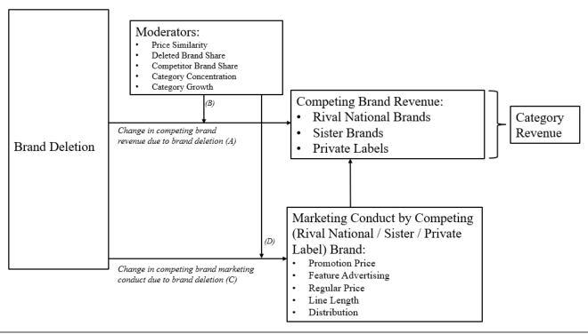

NOTE: figure/graphic rendered as an image from the PDF; its content is not machine-readable text. Caption (if any) follows as the next block.

Notes: Sister brands refer to brands owned by the same manufacturer as that of the deleted brand, rival national brands refer to brands owned by other manufacturers, and private labels refer to retailer-owned brands.

Page 11

Each competing brand can adjust its marketing conduct (captured by promotion price,

feature advertising, regular price, line length, and distribution in our FMCG context<sup>2</sup>) to steer

more revenue its way after a brand deletion (C in Figure 1). The direction of change can go either

way. When the focal brand is deleted, competition softens, and competing brands may reduce

marketing support (fewer price promotions or features, higher regular price, shorter line length,

and less distribution). Conversely, the deleted brand’s exit leaves a gap that competitors may

seek to fill by increasing their marketing support. Finally, we explore how the same moderators

shape these changes in competing brands’ marketing conduct after a brand deletion (D in Figure

1). For instance, depending on the deleted brand’s market share or the category concentration,

competing brands may respond more aggressively in adjusting their marketing conduct.

#### **DATA AND MEASURES *Deleted Brands***

For a broad investigation of what happens in the wake of a brand deletion, we focus on

all national brand deletions across all FMCG categories across a ten-year time period (2010–

2019) from any brand manufacturer, ranging from small to large. We hence do not consider

private label deletions. We identify brand deletions based on RMS NielsenIQ scanner data at the

market-retailer-category-brand-week level. These scanner data cover more than 1,300 product

categories in nine departments, such as health and beauty aids, food and beverages, dairy, and

non-food grocery products. We adopt the NielsenIQ definitions of categories, and give a

complete list of categories in our sample in Web Appendix A. We assume that all brands within a

category can be alternatives to the deleted brand, and if they are not, this will show up

empirically as null effects. As our focus is on brand deletions (rather than sub-brand deletions,

2 Brands often carry a narrower range of products at a specific retailer in a specific market than across all retailers and markets in the country. Thus, it is relatively easy for them to extend their line length at a specific retailer on short notice.

Page 12

which is more similar to previously-studied product line deletions), we aggregate NielsenIQ’s

sub-brands (e.g., “Air Wick Double Fresh”, “Air Wick Essential Mist”, “Air Wick Fresh Matic”,

and “Air Wick Hidden Pleasures”) to the brand level (“Air Wick”). We decide to keep the

NielsenIQ definitions of categories because they cater to different segments and have their own

price levels (and at times different measurement units) and differentiated marketing activities.

We screen all product categories and identify deletions from any category for any

national brand. We define a brand as deleted if it disappears from a product category and is

eventually deleted across all markets (DMAs) in the U.S and does not reappear for at least one

year. To ensure sufficient economic substance, we focus on deleted brands with (i) at least 52

weeks of observations, (ii) at least $10k in revenue across the U.S. in the year prior to the

deletion, and (iii) at least $100 in weekly sales at a given retailer and market before the deletion.

Thus, we identify 1,046 deleted national brands and show a selection in Table 2. Figure 2

provides an overview of the distribution of the deleted brands’ market shares prior to the

beginning of the deletion.

**Figure 2. Histogram of Deleted Brands’ Market Shares (N = 14,462)**

Delisted Brand's Market Share

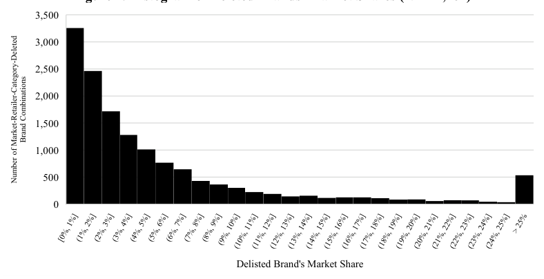

NOTE: figure/graphic rendered as an image from the PDF; its content is not machine-readable text. Caption (if any) follows as the next block.

**text found inside the figure**

Number of Market-Retailer-Category-Deleted

Brand Combinations

0

500

1,000

1,500

2,000

2,500

3,000

3,500

Page 13

**Table 2. Overview of Selection of Deleted Brands**

[output not shown]

NOTE: table converted from PDF layout to HTML text; cell boundaries are reconstructed. See PDF if exact alignment matters.

Sum =50,663 4,099 8,275 63,037 Notes: Total number of competing brands reflects the sum of competing brands in our sample across markets and retailers. We define deleted brands as having no sales and no distribution for at least one year. n.d. = not displayed; we do not show the number of market-retailer pairs if there are fewer than 5 to protect the retailer’s identity. a This is not the same as the total revenue in the U.S., but based on our sample frame, which is based on NielsenIQ’s sample of stores.

Brand deletions typically are not executed simultaneously across the entire U.S. at once

but rather occur sequentially, separately by markets (DMAs) and within markets, by retailers. We

account for the role of retailers as gatekeepers by analyzing brand deletions at the market-

retailer-brand level (14,462 market-retailer-deleted brand combinations). This allows us to

include retailer-specific marketing mix adjustments and retailer-specific moderators of the

treatment effect.

Within each market and retailer, a brand deletion is not an instantaneous event. A brand

deletion begins with a drop in its distribution (T0) and ends when the brand is no longer

distributed (T1). Distribution is the weighted average of the percentage of stores that carry the

Page 14

brand, where the weight is the store’s total annual revenue (all commodity value; Farris, Olver,

and De Kluyver 1989). To assess the beginning of the deletion, we smooth the distribution using

a moving average over 13 weeks. We then define T0 (beginning of the deletion) as the earlier of

either the last increase in distribution (i.e., no subsequent increase) before the downward slide

begins (98% of cases) or a cumulative drop in distribution that reaches at least 20% without

recovery to the previous distribution level (2% of cases).

Figure 3 depicts brand deletions for a simulated sample case: Talenti pulling out of the

frozen novelties category in one market at one retailer. Here, the beginning of the deletion period

is determined using the last increase in distribution prior to a downward slide. Figure W1 in Web

Appendix B shows the distribution of brand deletion periods across all brand deletions at the

market-retailer level in our sample. The average brand deletion period is 22 weeks, while more

than 30% are deleted within one week, and almost 90% within one year.

**Figure 3. Brand Deletion of Talenti from Frozen Novelties in One Market at One Retailer**

Notes: The black line shows the distribution over time. The first vertical red line marks the beginning of the deletion (T0), and the second red line indicates the end of the deletion (T1). The data are similar to cases in our sample but are simulated to protect retailers’ identities and are not based on NielsenIQ’s data.

In the analysis, we capture the brand deletion treatment as a continuous variable, ranging

from 0 before T0 when the deletion starts to 1 at time T1 when the deletion is complete. In the

transition period, the variable is the fraction of the deletion that has been completed, calculated

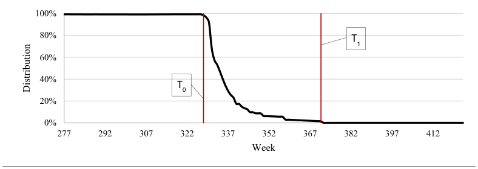

NOTE: figure/graphic rendered as an image from the PDF; its content is not machine-readable text. Caption (if any) follows as the next block.

**text found inside the figure**

0%

20%

40%

60%

80%

100%

277 292 307 322 337 352 367 382 397 412

Distribution

Week

T1

T0

Page 15

**equation / math rendering (image)**

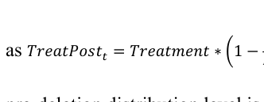

NOTE: contains mathematical notation; text above is the PDF text layer and symbols may be mis-extracted. Image shows the original.

**equation / math rendering (image)**

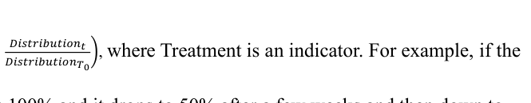

NOTE: contains mathematical notation; text above is the PDF text layer and symbols may be mis-extracted. Image shows the original.

nature of the treatment variable accounts for treatment effect changes during the deletion period.

#### *Competing Brands*

Our analysis focuses on how a brand deletion affects competing brands at the level of

individual retailers within markets. We study all market-retailer-category-brand deletion

combinations with a deletion period of up to 104 weeks at the market-retailer-category level. For

a clean analysis, we require no overlapping brand deletions in the same category in the deletion

period; if that is the case, the quasi-experiment is discarded. To ensure enough economic

substance, we include, for each market where the brand deletion happens, the market’s top 10

competing brands (i.e., rival national brands, sister brands, and private labels) with at least $100

revenue per week, market, and retailer on average, and the market’s top 3 retailers. We study all

available combinations of these top 10 brands at the top 3 retailers, noting that not every brand is

sold at every retailer. To ensure enough observations for inferences, we require at least 52 weeks

of sales data before and after the brand deletion (cf. Cleeren, van Heerde, and Dekimpe 2013).

Each competing brand may be a sister brand, which is a national brand owned by the

same brand manufacturer, a rival national brand owned by another brand manufacturer, or a

private label owned by the retailer. In total, we observe 6,031 unique competing brands,

potentially affected by the 1,046 brand deletions across markets and retailers.<sup>3</sup> As our focal unit

of analysis, we use market-retailer-category-brand combinations, reflecting the combination of a

3 Across markets and retailers, we observe 14,462 market-retailer-category-deleted brand combinations. In 95% (= 13,723/14,462), a rival national brand is present, in 57% (=8,275/14,462) a private label, and in 19% (=2,769/14,462) a sister brand.

Page 16

competing brand at a retailer within a market that potentially benefits from a brand deletion from

that same market and retailer. Our analysis includes competitor marketing mix variables to

account for changes in their marketing conduct prior to, during, and after the brand deletion. As

importantly, these variables can be actively adjusted: for instance, manufacturer-driven decisions

such as price promotions and feature advertising have frequently been shown to shift in response

to competitive shifts. Also, retailer decisions with manufacturers’ input, such as regular price and

line length, can be altered; the latter by launching SKUs that already exist in other markets. Even

a retailer-driven decision, such as distribution, though often high, is rarely 100% across all stores

in a market (not even for private labels), leaving scope for further adjustment. We note that a

retailer has, on average, 21.21 stores in a specific market.

To illustrate what market-retailer-category-brand pairs look like, let us consider the brand

deletion by Talenti from the frozen novelties category in a simulated market at one retailer

Bunny, Dreyer’s, Häagen-Dazs, M&M, Nestle, and The Skinny Cow, and there is one private

label. Therefore, this brand deletion potentially affects 10 competing brands.

#### *Variable Operationalization and Descriptive Statistics*

Table 3 lists the operationalizations of the variables used in the study, including value

sales (revenue), the marketing mix, and relevant control variables. We provide summary statistics

by deleted brand and type of competing brand in Table W1 of Web Appendix B. Web Appendix

C shows low to moderate correlations between the model variables, mitigating potential

multicollinearity concerns.

Page 17

**Table 3. Variable Operationalizations**

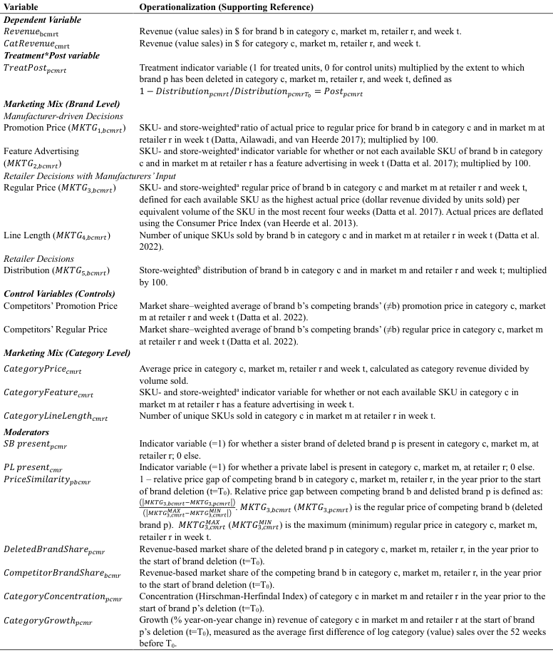

NOTE: complex table shown as an image of the PDF; the text below is a rough machine extraction and may be mis-aligned.

**extracted text (unreliable layout)**

a To aggregate SKU-level metrics to brand-level metrics, we compute weighted averages for the focal variables across a brand’s SKUs within each store that stocks the brand, using the SKU’s share of brand sales in the store as weights, for a rolling window of the previous 13 weeks. Then we aggregate across all stocking stores, with weights equal to each store’s share of total category sales in the same rolling window (Datta et al. 2017). We focus on all SKUs (after ordering them from largest to smallest sales) that collectively account for 95% of a brand’s sales within a calendar year.

b Weights are equal to each store’s share of total category sales in market m in a rolling window of the previous quarter. We use these weights to calculate retailerlevel distribution, which is the aggregate of store-level distribution where a brand is either present (1) or not (0).

Page 18

#### **METHOD**

To estimate the effect of a brand deletion on competing brand revenue and marketing

activity, our analysis proceeds as follows. We leverage a before–after–with–control setting to

estimate the treatment effect of a brand deletion on competing brands, at the market-retailer-

category-competing brand level (63,037 combinations). We use a difference-in-differences model

applied to data at the market (m)-retailer (r)-category (c)-competing brand (b)-week (t) level. The

model is augmented with moderators of the treatment effect and marketing mix effects. We also

estimate difference-in-differences models for the levels of the marketing mix variables of

competing brands, to assess how much they engage in marketing conduct changes.

We now discuss some identification challenges for estimating treatment effects and how

we address them. First, competing brands’ sales can change over time, even without the brand

deletion. To account for this possibility, we use as a control the *same* competing brand at the

*same* retailer in other markets. This approach accounts for seasonal effects and trends that affect

both the treated and control units. The fact that we observe “staggered treatment timing” for each

brand deletion and expect heterogeneous treatment effects requires special care because the

standard two-way fixed effects estimator may be biased (Goodman-Bacon 2021). We deal with

this as follows: we identify for each “treated” case (a market-retailer-category-deleted brand-

competing brand combination) a set of control units that consist of “not-yet-treated” cases. That

is, these “not-yet-treated” cases are not treated while they serve as a control unit, i.e., at least

until one year after the end of the post-deletion period, and as such, they present clean control

cases. We then stack all treated-control sets and estimate a difference-in-difference model with

extensive fixed effects for cross sections and time periods. Web Appendix D presents an

illustrative example of the data structure, highlighting that control units are never treated while

Page 19

they serve as controls. Moreover, as we highlight in the Robustness Check section, we also

estimate an alternative two-stage approach (Gardner et al. 2024) that explicitly takes the

staggered treatment timing into account, and find very comparable results.

Second, the timing of a brand manufacturer’s deletion decision for a given market and

retailer is unlikely to be random, and competing brands may strategically employ their marketing

mix to improve the share of revenue they gain after a brand deletion. We correct for the

endogeneity of the deletion decision and marketing mix using a control function approach with

Hausman-style instruments, explained below. Third, the deletion effect may be dynamic rather

than constant over time, as it may take a few weeks or months before the deletion is complete,

which we accommodate through our continuous *TreatPost* variable defined earlier.

#### *Treated and Control Units*

The treated units are competing brands sold at retailers in markets where the focal brand

is transitioning from being available to being deleted. To create a comparable control unit (i.e.,

where the focal brand is not deleted yet) for each treated unit, we select the possible controls to

match the treated units. We use as a control the same competing brand as the treated competing

brand in the same time period at the same retailer, but in different markets that still feature the

(not yet) deleted brand. For example, if competing brand b at retailer r in market 1 is potentially

benefiting from the deletion of brand p, we use brand b by retailer r in markets 2, 3, and 4 as

control units if brand p is still active in these markets. By using the same brand b and retailer r,

we ensure the treated and control brands are identical in general brand characteristics (e.g.,

publicity, national brand advertising) and retailer characteristics (e.g., fit of brand with retailer

positioning, strength of retailer). By design, this implies that the market(s) in which a brand b at

retailer r is deleted last will not have control unit.

Page 20

Thus, potential control units are the same competing brand, sold at the same retailer,

operating in all markets where the focal brand still operates. To find the most similar control

units, we match based on log weekly revenue and log marketing mix in the year prior to the start

of the deletion at time T0. Matching on the pretreatment outcome (log revenue) entails matching

on unobservable brand–market characteristics that relate to the outcome measure itself (Abadie

2021), which is desirable because it means the analysis accounts for unobservables.<sup>4</sup> For each

potential control, we calculate the correlations between the treated unit’s and potential control

unit’s weekly log revenue and five log marketing mix variables across these 52 weeks. To ensure

parallel trends pretreatment, we select for each treated unit up to 10 control units (in line with,

e.g., Bollinger and Sexton 2023, p. 292; Keller and Guyt 2025, pp. 11-12) that each must have an

average correlation of at least .8 with the treated unit across these six variables. A correlation of

.8 is typically considered high, and we note that this threshold already leads to a high average

pretreatment correlation of > .89 (Table 4) between treated and control units. However, we

acknowledge that it is an arbitrary threshold and assess the robustness of our findings to even

higher thresholds of .85 and .90, respectively (see Additional Checks section).

**Table 4. Pretreatment Correlations between Treated and Control Units by Brand Type**

[output not shown]

NOTE: table converted from PDF layout to HTML text; cell boundaries are reconstructed. See PDF if exact alignment matters.

4 It is possible to consider other variables in defining control units. However, our approach is to define control markets as similar to the treatment market by considering how similar revealed brand preferences (revenue) and revealed marketing mix activity (marketing variables) are between markets. Underlying these similarities (e.g. preferences for budget brands) may be certain demographics (e.g., low wages), but we believe it is more direct to use observed preferences and marketing mix conduct to find control units similar to the treated unit.

Page 21

#### *Parallel Trends*

A key assumption of the difference-in-differences model is that the treated unit’s outcome

would have been the control unit’s outcome in the absence of the treatment. We cannot test the

posttreatment parallel trends assumption, because the counterfactual outcome is not observed,

but we can assess whether treated and control units evolve in parallel prior to the treatment.

Figure 4a shows visual evidence of parallel trends for revenue, with an average pretreatment

correlation of .998. Figure 4b shows the pretreatment deviation test (where we control for cross-

section and time fixed effects). For 50 [48] out of 52 weeks, there is no statistical difference

(*p*>.05) [*p*>.1], which is close to what is expected by chance.<sup>5</sup> We also conduct an in-time

placebo test, where we set the treatment date 26 weeks before the actual treatment. The

difference is negligible (b = -.001, *p*=.837), confirming pretreatment parallel trends.

**Figure 4. Evidence for Pretreatment Parallel Trends**

Panel a: Parallel Pretreatment Trends for

Treated and Control Units (r = .998)

Panel b: Pretreatment Deviation Test for

Treated vs. Control Units

Notes: Panel A shows the aggregate evolution of revenue before the beginning of the deletion (T0), separately for treated and control units. Web Appendix E shows the evolution by outcome variable at a more disaggregate level. Panel B shows the parameter estimates of the pretreatment deviation test, where each dot is an estimate representing the difference between treated and control units, with the estimate of the immediate week before T0 (-1) serving as baseline. Bars show 95% confidence intervals. We provide detailed parameter estimates in Web Appendix F. *Model-Free Evidence of Brand Deletion Effects on Competing Brands*

To provide first insights into how brand deletions affect competing brand sales and

5 The four lowest *p*-values are .005, .014, .077, and .080, respectively.

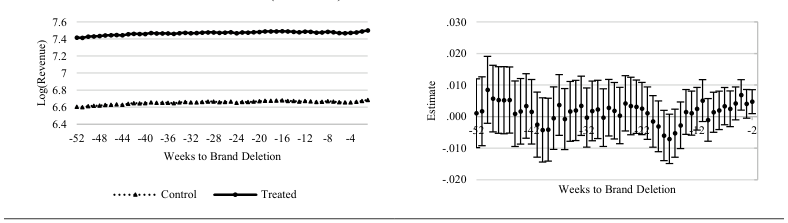

NOTE: figure/graphic rendered as an image from the PDF; its content is not machine-readable text. Caption (if any) follows as the next block.

**text found inside the figure**

6.4 6.6 6.8 7 7.2 7.4 7.6

-52 -48 -44 -40 -36 -32 -28 -24 -20 -16 -12 -8 -4

Log(Revenue)

Weeks to Brand Deletion

Control Treated

-.020

-.010

.000

.010

.020

.030

-52 -42 -32 -22 -12 -2

Estimate

Weeks to Brand Deletion

Page 22

marketing conduct, Table 5 presents the average relative change in revenue and the marketing

mix before the deletion started (52 weeks before), and 52 weeks after the deletion finished. Table

5 is based on averaging (63,037) case-specific values, comparing for each case the before-after

differences of treated and (average) control units. We do this separately for rival national brands,

sister brands, and private labels.

**Table 5. Model-free Evidence on Changes in Outcome Metrics**

[output not shown]

NOTE: table converted from PDF layout to HTML text; cell boundaries are reconstructed. See PDF if exact alignment matters.

Notes: To minimize the impact of outliers at the case-level, we trim the case-specific effects at the 1<sup>st</sup>/99<sup>th</sup> level.

Table 5 shows that revenue changes notably for all brand types. After the deletion, all

three brand types gain sales, at between 1.19% and 1.57% of their before-deletion levels. In

terms of marketing variables, we find that while promotion prices hardly change, feature

advertising, regular price, line length, and distribution generally increase following the deletion.

Noting the usual caveats regarding model-free comparisons, we turn to our formal analysis to

provide cleaner estimates of brand deletion effects.

#### *Difference-in-Differences Model for Brand Revenue*

As discussed, the treatment and control pairs meet the pretreatment parallel-trends

assumption. Following Li and Van den Bulte (2023, p. 751), “if the testable part of the DID

parallel trends assumption holds, then use the DID method,” we adopt a moderated difference-in-

differences model. We stack weekly observations for all treated units and all control units (up to

10 per treated unit), for a total of 55,876,309 observations across all market-retailer-category-

Page 23

brand-week combinations. We estimate a moderated difference-in-differences model for the

effect of brand deletion on competing brand revenue, accounting for moderators, marketing mix

effects and changes therein, control variables, and endogeneity control functions:

**equation / math rendering (image)**

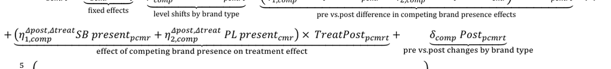

NOTE: contains mathematical notation; text above is the PDF text layer and symbols may be mis-extracted. Image shows the original.

**equation / math rendering (image)**

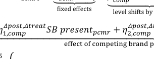

NOTE: contains mathematical notation; text above is the PDF text layer and symbols may be mis-extracted. Image shows the original.

**equation / math rendering (image)**

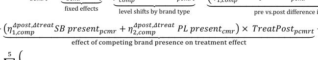

NOTE: contains mathematical notation; text above is the PDF text layer and symbols may be mis-extracted. Image shows the original.

effect of competing brand presence on treatment effect

**equation / math rendering (image)**

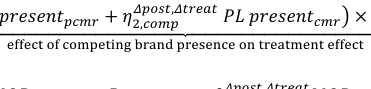

NOTE: contains mathematical notation; text above is the PDF text layer and symbols may be mis-extracted. Image shows the original.

**equation / math rendering (image)**

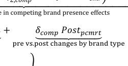

NOTE: contains mathematical notation; text above is the PDF text layer and symbols may be mis-extracted. Image shows the original.

**equation / math rendering (image)**

NOTE: contains mathematical notation; text above is the PDF text layer and symbols may be mis-extracted. Image shows the original.

**equation / math rendering (image)**

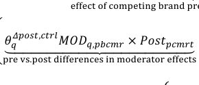

NOTE: contains mathematical notation; text above is the PDF text layer and symbols may be mis-extracted. Image shows the original.

pre vs.post differences in moderator effects

**equation / math rendering (image)**

NOTE: contains mathematical notation; text above is the PDF text layer and symbols may be mis-extracted. Image shows the original.

**equation / math rendering (image)**

NOTE: contains mathematical notation; text above is the PDF text layer and symbols may be mis-extracted. Image shows the original.

**equation / math rendering (image)**

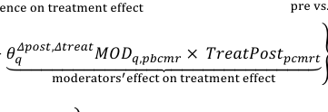

NOTE: contains mathematical notation; text above is the PDF text layer and symbols may be mis-extracted. Image shows the original.

moderators<sup>′</sup>effect on treatment effect

**equation / math rendering (image)**

NOTE: contains mathematical notation; text above is the PDF text layer and symbols may be mis-extracted. Image shows the original.

**equation / math rendering (image)**

NOTE: contains mathematical notation; text above is the PDF text layer and symbols may be mis-extracted. Image shows the original.

5

**equation / math rendering (image)**

NOTE: contains mathematical notation; text above is the PDF text layer and symbols may be mis-extracted. Image shows the original.

𝑞𝑞=1

**equation / math rendering (image)**

NOTE: contains mathematical notation; text above is the PDF text layer and symbols may be mis-extracted. Image shows the original.

**equation / math rendering (image)**

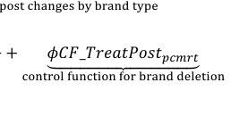

NOTE: contains mathematical notation; text above is the PDF text layer and symbols may be mis-extracted. Image shows the original.

**equation / math rendering (image)**

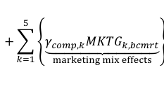

NOTE: contains mathematical notation; text above is the PDF text layer and symbols may be mis-extracted. Image shows the original.

marketing mix effects

**equation / math rendering (image)**

NOTE: contains mathematical notation; text above is the PDF text layer and symbols may be mis-extracted. Image shows the original.

ቑ

**equation / math rendering (image)**

NOTE: contains mathematical notation; text above is the PDF text layer and symbols may be mis-extracted. Image shows the original.

5

**equation / math rendering (image)**

NOTE: contains mathematical notation; text above is the PDF text layer and symbols may be mis-extracted. Image shows the original.

𝑘𝑘=1

**equation / math rendering (image)**

NOTE: contains mathematical notation; text above is the PDF text layer and symbols may be mis-extracted. Image shows the original.

+ ෍

**equation / math rendering (image)**

NOTE: contains mathematical notation; text above is the PDF text layer and symbols may be mis-extracted. Image shows the original.

**equation / math rendering (image)**

NOTE: contains mathematical notation; text above is the PDF text layer and symbols may be mis-extracted. Image shows the original.

**equation / math rendering (image)**

NOTE: contains mathematical notation; text above is the PDF text layer and symbols may be mis-extracted. Image shows the original.

**equation / math rendering (image)**

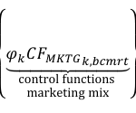

NOTE: contains mathematical notation; text above is the PDF text layer and symbols may be mis-extracted. Image shows the original.

control functions

**equation / math rendering (image)**

NOTE: contains mathematical notation; text above is the PDF text layer and symbols may be mis-extracted. Image shows the original.

**equation / math rendering (image)**

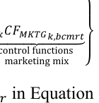

NOTE: contains mathematical notation; text above is the PDF text layer and symbols may be mis-extracted. Image shows the original.

**equation / math rendering (image)**

NOTE: contains mathematical notation; text above is the PDF text layer and symbols may be mis-extracted. Image shows the original.

5

**equation / math rendering (image)**

NOTE: contains mathematical notation; text above is the PDF text layer and symbols may be mis-extracted. Image shows the original.

𝑘𝑘=1

**equation / math rendering (image)**

NOTE: contains mathematical notation; text above is the PDF text layer and symbols may be mis-extracted. Image shows the original.

**equation / math rendering (image)**

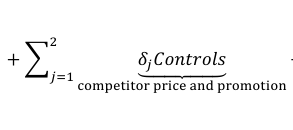

NOTE: contains mathematical notation; text above is the PDF text layer and symbols may be mis-extracted. Image shows the original.

2

**equation / math rendering (image)**

NOTE: contains mathematical notation; text above is the PDF text layer and symbols may be mis-extracted. Image shows the original.

𝑗𝑗=1

**equation / math rendering (image)**

NOTE: contains mathematical notation; text above is the PDF text layer and symbols may be mis-extracted. Image shows the original.

**equation / math rendering (image)**

NOTE: contains mathematical notation; text above is the PDF text layer and symbols may be mis-extracted. Image shows the original.

The fixed effects 𝛼𝛼𝑏𝑏𝑏𝑏𝑏𝑏𝑏𝑏 in Equation 1 account for unobserved level differences in brand

revenue specific to brand b in category c in market m and at retailer r (the cross section). The

fixed effects 𝛼𝛼𝑡𝑡 account for any time-varying unobservables such as trends. The first effect of

interest is 𝛽𝛽1,𝑐𝑐𝑐𝑐𝑐𝑐𝑐𝑐, which is the effect of brand p’s deletion on revenue the competing brand

post changes in sales through 𝑃𝑃𝑜𝑜𝑜𝑜𝑡𝑡𝑝𝑝𝑝𝑝𝑝𝑝𝑝𝑝𝑝𝑝.<sup>6</sup>

**equation / math rendering (image)**

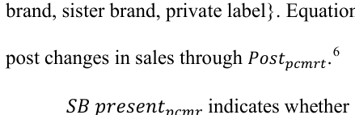

NOTE: contains mathematical notation; text above is the PDF text layer and symbols may be mis-extracted. Image shows the original.

𝑆𝑆𝑆𝑆 𝑝𝑝𝑝𝑝𝑝𝑝𝑝𝑝𝑝𝑝𝑝𝑝𝑡𝑡𝑝𝑝𝑝𝑝𝑝𝑝𝑝𝑝 indicates whether a sister brand of the deleted brand p is active in the

category at that retailer and market. Similarly, 𝑃𝑃𝑃𝑃 𝑝𝑝𝑝𝑝𝑝𝑝𝑝𝑝𝑝𝑝𝑝𝑝𝑡𝑡𝑐𝑐𝑐𝑐𝑐𝑐 reflects whether a private label is

**equation / math rendering (image)**

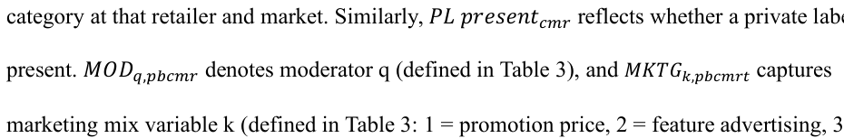

NOTE: contains mathematical notation; text above is the PDF text layer and symbols may be mis-extracted. Image shows the original.

marketing mix variable k (defined in Table 3: 1 = promotion price, 2 = feature advertising, 3 =

6 𝑃𝑃𝑜𝑜𝑜𝑜𝑡𝑡𝑝𝑝𝑝𝑝𝑝𝑝𝑝𝑝𝑝𝑝 has a subscript p to indicate that the same market-retailer-category-competing brand combination may appear multiple times in the data. This occurs because it can serve as control for different treated cases and, if the brand deletion timing differs, the 𝑃𝑃𝑜𝑜𝑜𝑜𝑡𝑡𝑝𝑝𝑝𝑝𝑝𝑝𝑝𝑝𝑝𝑝 variable may take on different details. As such, subscript p technically has its own subscripts for category (c), market (m), and retailer (r) because a deletion of brand p happens at the market-retailer-category level. We omit these for readability reasons.

**equation / math rendering (image)**

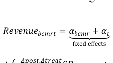

NOTE: contains mathematical notation; text above is the PDF text layer and symbols may be mis-extracted. Image shows the original.

ϐixed effects

**equation / math rendering (image)**

NOTE: contains mathematical notation; text above is the PDF text layer and symbols may be mis-extracted. Image shows the original.

**equation / math rendering (image)**

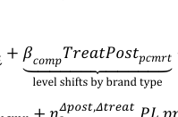

NOTE: contains mathematical notation; text above is the PDF text layer and symbols may be mis-extracted. Image shows the original.

level shifts by brand type

**equation / math rendering (image)**

NOTE: contains mathematical notation; text above is the PDF text layer and symbols may be mis-extracted. Image shows the original.

**equation / math rendering (image)**

NOTE: contains mathematical notation; text above is the PDF text layer and symbols may be mis-extracted. Image shows the original.

**equation / math rendering (image)**

NOTE: contains mathematical notation; text above is the PDF text layer and symbols may be mis-extracted. Image shows the original.

**equation / math rendering (image)**

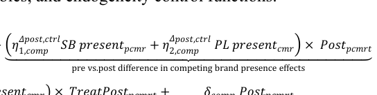

NOTE: contains mathematical notation; text above is the PDF text layer and symbols may be mis-extracted. Image shows the original.

pre vs.post difference in competing brand presence effects

**equation / math rendering (image)**

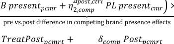

NOTE: contains mathematical notation; text above is the PDF text layer and symbols may be mis-extracted. Image shows the original.

(1)

**equation / math rendering (image)**

NOTE: contains mathematical notation; text above is the PDF text layer and symbols may be mis-extracted. Image shows the original.

Page 24

**equation / math rendering (image)**

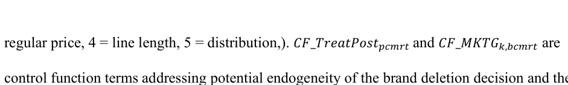

NOTE: contains mathematical notation; text above is the PDF text layer and symbols may be mis-extracted. Image shows the original.

control function terms addressing potential endogeneity of the brand deletion decision and the

marketing mix, respectively. 𝐶𝐶𝐶𝐶𝐶𝐶𝐶𝐶𝐶𝐶𝐶𝐶𝐶𝐶𝐶𝐶 includes the weighted average competitor regular price

(j=1) and promotion price (j=2), as defined in Table 3. All marketing mix variables are mean-

centered within a cross section, and all moderators are mean-centered (as they are constant

within a cross-section). The main effects of 𝑇𝑇𝑇𝑇𝑇𝑇𝑇𝑇𝑡𝑡𝑝𝑝𝑝𝑝𝑝𝑝𝑝𝑝 and its interaction effects with (the time-

invariant) 𝑀𝑀𝑀𝑀𝐷𝐷𝑞𝑞,𝑝𝑝𝑝𝑝𝑝𝑝𝑝𝑝𝑝𝑝 variables are subsumed in the fixed effects 𝛼𝛼𝑏𝑏𝑏𝑏𝑏𝑏𝑏𝑏.

**equation / math rendering (image)**

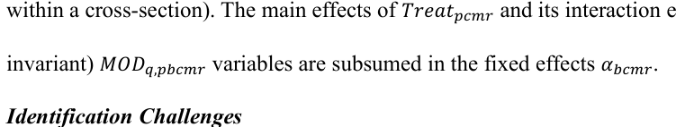

NOTE: contains mathematical notation; text above is the PDF text layer and symbols may be mis-extracted. Image shows the original.

#### *Identification Challenges*

The treated versus control unit approach accounts for unobservables that could drive the

revenue change, but we note other potential threats to identification that require attention,

including the timing of the brand deletion and the endogenous nature of marketing mix tools.

*Endogeneity of the timing of brand deletion*

The order in which a brand manufacturer deletes a brand from different markets and

retailers may not be random but instead could be determined by the strength of the remaining

sister brands in these markets or other unobserved factors. Endogenous timing of the brand

this variable, in which case the parameter estimates of Equation 1 may be inconsistent

(Wooldridge 2010). To address this concern, we specify a first-stage model using exogenous

variation to explain the extent to which brand p is deleted from competing brand b’s category c

the residual 𝐶𝐶𝐶𝐶_𝑇𝑇𝑇𝑇𝑇𝑇𝑇𝑇𝑇𝑇𝑇𝑇𝑇𝑇𝑇𝑇𝑇𝑇𝑝𝑝𝑝𝑝𝑝𝑝𝑝𝑝𝑝𝑝 and include it in Equation 1 to alleviate the endogeneity

**equation / math rendering (image)**

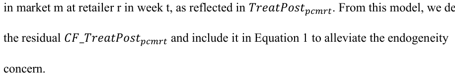

NOTE: contains mathematical notation; text above is the PDF text layer and symbols may be mis-extracted. Image shows the original.

concern.

Page 25

meet the criteria of strength, validity, and granularity (Shi, Grewal, and Sridhar 2021), i.e., it

should (1) correlate with the outcome variable (whether a brand is deleted), (2) not affect the

unobserved parts of competing brands’ revenues, and (3) vary at the same level as the data.

Following Sridhar et al. (2016) and Keller and Guyt (2023), we leverage institutional

insights to determine an appropriate instrument, namely, the share of neighbors-of-neighboring

markets in which the brand has already been deleted at the retailer. A market (DMA) has

neighboring markets, which in turn have their own neighbors, which we define as neighbors of

neighbors. For example, the Lafayette, LA, market has three neighbors (Lake Charles, LA,

Alexandria, LA, and Baton Rouge, LA). Lake Charles, LA, has one neighbor that is not a

neighbor of Lafayette, LA (Beaumont-Port Arthur), Alexandria, LA, has two (Shreveport and

Monroe-El Dorado), and Baton Rouge’s neighbors include New Orleans, LA, and Jackson, MS.

Together, these 5 markets are Lafayette’s neighbors’ neighbors. If two out of these five neighbors

have deleted the brand already, the instrument takes the value .4 (=2/5).

The rationale for the instrument is as follows. Brands are typically managed and

distributed by geographic regions covering multiple markets. The decision to delete a brand from

a region is usually made for all markets in that region, regardless of individual market

performance. Even if a single market represents a success, it may not be enough to support the

overall overhead costs of distributing and managing the entire region. Because contracts and

inventory levels vary across retailers and markets, the brand does not disappear simultaneously

but sequentially, so brand deletions in neighbors-of-neighboring markets could be informative

about whether a deletion is imminent for the focal market (leading to instrument strength; see

also Hwang, Bronnenberg, and Thomadsen (2010) and Keller and Guyt (2023)). Whether a brand

Page 26

is deleted in neighbors-of-neighboring markets (hundreds of miles away) should not affect

demand for that brand in the focal market, as consumers do not travel hundreds of miles for

grocery shopping (creating instrument validity, i.e., meeting the exclusion restriction). We focus

on neighbors’ neighbors (rather than direct neighbors) to avoid potential cross-market demand

spillovers. The share of neighbors’ neighbors where the brand has already been delisted at a

given retailer varies at the same level as our data, so this instrumental variable also meets the

granularity criterion. Finally, we note that the instrument in the first-stage regression is positively

and strongly related to the brand deletion decision (𝑏𝑏 = .513, *p* < .001); see Web Appendix G.

*Endogeneity of the marketing mix*

Brand managers may be strategic in setting their marketing mix, and those decisions can

be driven by unobserved demand shocks that vary cross-sectionally or over time. Cross-sectional

shocks reflect unobserved differences across market-retailer-brand combinations, such that a

brand may be more popular in some markets and therefore command a price premium. To

safeguard against this potential endogeneity concern, we only use within-market-retailer-

category-brand variation by including market-retailer-category-brand fixed effects 𝛼𝛼𝑏𝑏𝑏𝑏𝑏𝑏𝑏𝑏. The

unobserved brand factors could also be time-varying (see, e.g., Papies, Ebbes, and van Heerde

2017), but the quasi-experimental method and chosen control units implicitly account for time-

varying brand-specific factors’ effect on the treatment effect (e.g., national brand advertising),

because the control units pertain to the same brand at the same time.

What remains are time-varying factors specific to a given market-retailer-category-brand

pair, as when brands strategically adjust their marketing mix response locally at a given market

or retailer. To address this source of endogeneity, we use a control function approach with

Hausman-style instruments. For example, for regular price, the instrumental variable is the

Page 27

average regular price of the same brand b at the same retailer in neighbors’ neighboring markets

in the same week. In the first stage, we regress all marketing mix variables on the instrumental

variables and control variables, and include the residuals (𝐶𝐶𝐶𝐶_𝑀𝑀𝑀𝑀𝑀𝑀𝑀𝑀𝑘𝑘,𝑏𝑏𝑏𝑏𝑏𝑏𝑏𝑏𝑏𝑏) in Equation 1.

The rationale for instrument relevance for regular price is that underlying cost factors for

ingredients, packaging, transportation, and labor may exhibit regional and longitudinal variation,

affecting regular prices both in the focal market and its neighbors’ neighbors (see also Ma et al.

(2011) and Keller and Guyt (2023)). The identifying assumption is that markets operate in

comparable economic environments and face similar cost shocks (e.g., due to price fluctuations

or transportation costs), which influence marketing mix decisions. Thus, changes in the

marketing mix at the same retailer in markets that are neighbors’ neighbors should correlate with

changes in the marketing mix for the retailer in focal markets, implying that the instrument is

relevant and strong. Indeed, we find that the instruments in the first-stage regressions are all

positively related to the endogenous variables (parameters range from .722 to .942, all *p* < .001),

attesting to the instruments’ strength. Multivariate Sanderson-Windmeijer tests also attest to the

strength of each instrument (all *p* < .001); see Web Appendix G for details.

To satisfy the exclusion restriction, no common demand shocks should affect both

markets, which is why we use neighbors’ neighbors markets, as before. Because we aggregate

across all neighbors’ neighboring markets, it is unlikely that the instrument is affected by market-

level idiosyncratic shocks (Sridhar et al. 2016). Therefore, we argue that the instruments are

valid and satisfy the exclusion restriction. Finally, instruments need to exhibit sufficient

granularity (Shi et al. 2021). In our case, they do; the average marketing mix across neighbors’

neighboring markets in a given week varies at the same level (across markets, retailers,

Page 28

categories, brands, and time) as our focal marketing mix variable.<sup>7</sup>

We estimate Equation 1 (and 2 below) with OLS using clustered errors at the retailer-

category-brand level to account for potential autocorrelation and correlation across markets.

Following Papies et al. (2017), we adjust the standard errors to reflect that the control function

terms are estimated quantities.

#### *Difference-in-Differences Model for Marketing Mix*

To assess the extent to which competing brands actively change their marketing support

in the wake of the brand deletion, we use the same quasi-experimental approach as for brand

revenue. Stacking the same observations (where the same treated units are paired with the same

up to 10 control units), we now estimate a difference-in-differences model for each marketing

variable (k=1,…,5) separately:

**equation / math rendering (image)**

NOTE: contains mathematical notation; text above is the PDF text layer and symbols may be mis-extracted. Image shows the original.

ϐixed effects

**equation / math rendering (image)**

NOTE: contains mathematical notation; text above is the PDF text layer and symbols may be mis-extracted. Image shows the original.

**equation / math rendering (image)**

NOTE: contains mathematical notation; text above is the PDF text layer and symbols may be mis-extracted. Image shows the original.

level shifts by brand type

**equation / math rendering (image)**

NOTE: contains mathematical notation; text above is the PDF text layer and symbols may be mis-extracted. Image shows the original.

**equation / math rendering (image)**

NOTE: contains mathematical notation; text above is the PDF text layer and symbols may be mis-extracted. Image shows the original.

**equation / math rendering (image)**

NOTE: contains mathematical notation; text above is the PDF text layer and symbols may be mis-extracted. Image shows the original.

**equation / math rendering (image)**

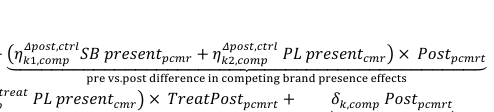

NOTE: contains mathematical notation; text above is the PDF text layer and symbols may be mis-extracted. Image shows the original.

pre vs.post difference in competing brand presence effects

**equation / math rendering (image)**

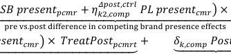

NOTE: contains mathematical notation; text above is the PDF text layer and symbols may be mis-extracted. Image shows the original.

(2)

**equation / math rendering (image)**

NOTE: contains mathematical notation; text above is the PDF text layer and symbols may be mis-extracted. Image shows the original.

**equation / math rendering (image)**

NOTE: contains mathematical notation; text above is the PDF text layer and symbols may be mis-extracted. Image shows the original.

**equation / math rendering (image)**

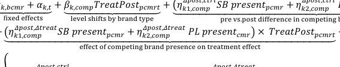

NOTE: contains mathematical notation; text above is the PDF text layer and symbols may be mis-extracted. Image shows the original.

effect of competing brand presence on treatment effect

**equation / math rendering (image)**

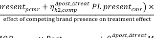

NOTE: contains mathematical notation; text above is the PDF text layer and symbols may be mis-extracted. Image shows the original.

**equation / math rendering (image)**

NOTE: contains mathematical notation; text above is the PDF text layer and symbols may be mis-extracted. Image shows the original.

pre vs.post changes by brand type

**equation / math rendering (image)**

NOTE: contains mathematical notation; text above is the PDF text layer and symbols may be mis-extracted. Image shows the original.

**equation / math rendering (image)**

NOTE: contains mathematical notation; text above is the PDF text layer and symbols may be mis-extracted. Image shows the original.

**equation / math rendering (image)**

NOTE: contains mathematical notation; text above is the PDF text layer and symbols may be mis-extracted. Image shows the original.

accounts for pre vs.post differences in moderator effects

**equation / math rendering (image)**

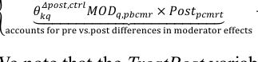

NOTE: contains mathematical notation; text above is the PDF text layer and symbols may be mis-extracted. Image shows the original.

**equation / math rendering (image)**

NOTE: contains mathematical notation; text above is the PDF text layer and symbols may be mis-extracted. Image shows the original.

**equation / math rendering (image)**

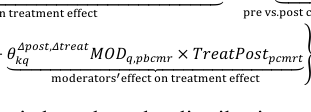

NOTE: contains mathematical notation; text above is the PDF text layer and symbols may be mis-extracted. Image shows the original.

moderators<sup>′</sup>effect on treatment effect

**equation / math rendering (image)**

NOTE: contains mathematical notation; text above is the PDF text layer and symbols may be mis-extracted. Image shows the original.

**equation / math rendering (image)**

NOTE: contains mathematical notation; text above is the PDF text layer and symbols may be mis-extracted. Image shows the original.

5

**equation / math rendering (image)**

NOTE: contains mathematical notation; text above is the PDF text layer and symbols may be mis-extracted. Image shows the original.

𝑞𝑞=1

**equation / math rendering (image)**

NOTE: contains mathematical notation; text above is the PDF text layer and symbols may be mis-extracted. Image shows the original.

**equation / math rendering (image)**

NOTE: contains mathematical notation; text above is the PDF text layer and symbols may be mis-extracted. Image shows the original.

control function for brand deletion

**equation / math rendering (image)**

NOTE: contains mathematical notation; text above is the PDF text layer and symbols may be mis-extracted. Image shows the original.

**equation / math rendering (image)**

NOTE: contains mathematical notation; text above is the PDF text layer and symbols may be mis-extracted. Image shows the original.

We note that the *TreatPost* variable is based on the distribution of the deleted brand p

(which goes to zero eventually), while one of the marketing variables is the distribution of

competing brand b. This separation ensures there is no circularity in the model.

#### *Difference-in-Differences Model for Category Revenue*

To assess what happens with category revenue in the wake of the brand deletion, we use a

similar quasi-experimental approach as for brand revenue. After identifying up to 10 control

units for each treated unit, we specify a difference-in-differences model for category revenue

7 We note that peer groups need to be partially overlapping (Angrist 2014; Shi et al. 2021), as is true in our study setting, because we use the same brand sold at the same retailer in different markets and because we only include markets where the brand is still active (resulting in different peer groups within brands).

Page 29

(3)

**equation / math rendering (image)**

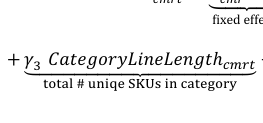

NOTE: contains mathematical notation; text above is the PDF text layer and symbols may be mis-extracted. Image shows the original.

total # uniqe SKUs in category

**equation / math rendering (image)**

NOTE: contains mathematical notation; text above is the PDF text layer and symbols may be mis-extracted. Image shows the original.

**equation / math rendering (image)**

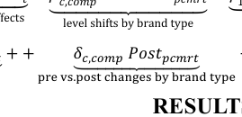

NOTE: contains mathematical notation; text above is the PDF text layer and symbols may be mis-extracted. Image shows the original.

**equation / math rendering (image)**

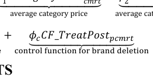

NOTE: contains mathematical notation; text above is the PDF text layer and symbols may be mis-extracted. Image shows the original.

**equation / math rendering (image)**

NOTE: contains mathematical notation; text above is the PDF text layer and symbols may be mis-extracted. Image shows the original.

#### *Difference-in-Differences Model Results for Brand Revenue*

To understand the effect of brand deletion on competing brand revenue, we turn to the

corresponding difference-in-differences model (Equation 1), the results of which are in Table 6.

The model fits the data well (R<sup>2</sup> = .848) and collinearity does not appear to be an issue, as also

confirmed in Web Appendix J, where we incrementally add blocks of variables to the model,

starting with just intercept shifts. Web Appendix C also provides a correlation matrix among the

key variables. Most of the control function terms are significant at the 10% level, indicating the

relevance of accounting for the endogeneity of marketing conduct and the delisting decision. We

do note that Web Appendix J shows that directionally, the findings are not different when we

leave out the control function terms.

#### *Results for Brand Deletion Effects on Competing Brand Revenues*

labels gain revenue (b=.021, *p*=.035)<sup>9</sup>. These effects hold for moderators and marketing mix kept

at their means, as all covariates are mean-centered. However, as discussed below in Table 9,

8 In an auxiliary analysis, we also measure the impact of a brand deletion on whether retailers launch new brands in the category. Specifically, we assess whether the rate of new brands (measured in three ways: brands (i) new to the market-retailer pair, (ii) new to the market, and (iii) new to the category) differs between market-retailer-category combinations with a brand deletion versus its control markets. Using a difference-in-difference specification, we find that the rate of launching new brands is not different depending on whether a brand deletion takes place or not. Please see Web Appendix I for details. 9 To arrive at percentage changes, we transform the intercept shifts by (eb-1)*100%.

**equation / math rendering (image)**

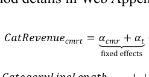

NOTE: contains mathematical notation; text above is the PDF text layer and symbols may be mis-extracted. Image shows the original.

ϐixed effects

**equation / math rendering (image)**

NOTE: contains mathematical notation; text above is the PDF text layer and symbols may be mis-extracted. Image shows the original.

**equation / math rendering (image)**

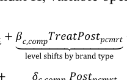

NOTE: contains mathematical notation; text above is the PDF text layer and symbols may be mis-extracted. Image shows the original.

level shifts by brand type

**equation / math rendering (image)**

NOTE: contains mathematical notation; text above is the PDF text layer and symbols may be mis-extracted. Image shows the original.

**equation / math rendering (image)**

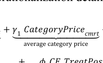

NOTE: contains mathematical notation; text above is the PDF text layer and symbols may be mis-extracted. Image shows the original.

average category price

**equation / math rendering (image)**

NOTE: contains mathematical notation; text above is the PDF text layer and symbols may be mis-extracted. Image shows the original.

**equation / math rendering (image)**

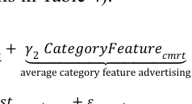

NOTE: contains mathematical notation; text above is the PDF text layer and symbols may be mis-extracted. Image shows the original.

average category feature advertising

**equation / math rendering (image)**

NOTE: contains mathematical notation; text above is the PDF text layer and symbols may be mis-extracted. Image shows the original.

Page 30

when we take the moderators and marketing mix conduct into account, the insights change.

**Table 6. Effect of Brand Deletion, Moderators, Marketing Mix on Competitor Revenue**

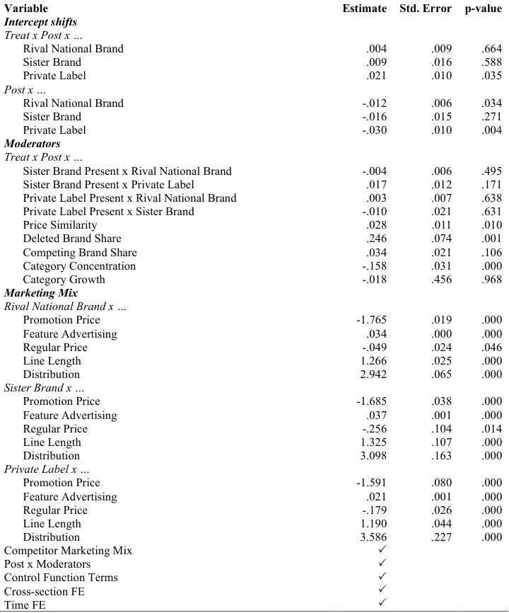

NOTE: complex table shown as an image of the PDF; the text below is a rough machine extraction and may be mis-aligned.

**extracted text (unreliable layout)**

Variable ; Estimate ; Std Error . ; p-value | Interceptshifts TreatxPostx … RivalNationalBrand SisterBrand PrivateLabel ; 004 . 009 . 021 . ; 009 . 016 . 010 . ; 664 . 588 . 035 . | Postx … RivalNationalBrand SisterBrand PrivateLabel ; 012 -. 016 -. 030 -. ; 006 . 015 . 010 . ; 034 . 271 . 004 . | Moderators TreatxPostx … SisterBrandPresentxRivalNationalBrand SisterBrandPresentxPrivateLabel PrivateLabelPresentxRivalNationalBrand PrivateLabelPresentxSisterBrand PriceSimilarity DeletedBrandShare CompetingBrandShare CategoryConcentration CategoryGrowth ; 004 -. 017 . 003 . 010 -. 028 . 246 . 034 . 158 -. 018 -. ; 006 . 012 . 007 . 021 . 011 . 074 . 021 . 031 . 456 . ; 495 . 171 . 638 . 631 . 010 . 001 . 106 . 000 . 968 . | MarketingMix RivalNationalBrandx … PromotionPrice FeatureAdvertising RegularPrice LineLength Distribution ; 1765 - . 034 . 049 -. 1266 . 2942 . ; 019 . 000 . 024 . 025 . 065 . ; 000 . 000 . 046 . 000 . 000 . | SisterBrandx … PromotionPrice FeatureAdvertising RegularPrice LineLength Distribution ; 1685 - . 037 . 256 -. 1325 . 3098 . ; 038 . 001 . 104 . 107 . 163 . ; 000 . 000 . 014 . 000 . 000 . | PrivateLabelx … PromotionPrice FeatureAdvertising RegularPrice LineLength Distribution CompetitorMarketingMix PostxModerators ControlFunctionTerms Cross-section FE TimeFE ; 1591 - . 021 . 179 -. 1190 . 3586 .      ; 080 . 001 . 026 . 044 . 227 . ; 000 . 000 . 000 . 000 . 000 .

Table 6 shows that competing brands gain more revenue when they are more similarly

priced to the deleted brand (b=.028, *p*=.010), indicating consumers may switch to similarly-

Page 31

priced competitors rather than brands with a different price positioning. Competing brands also

gain when the deleted brand had a higher market share (b=.246, *p*<.001), which makes sense as

there is more demand to redistribute. A higher category concentration limits the gain for

competing brands (b=-.158, *p*<.001), as consumers may find it harder to find a substitute in a

positioned to scoop up revenue from the deleted brand. The category growth does not materially

affect the revenue of competing brands.

#### *Results for Marketing Mix Effectiveness*

Both the dependent variable and the marketing mix covariates are in log form, and the

parameters can be interpreted as elasticities with respect to revenue. The parameter estimates for

the marketing mix are face valid. The promotional price elasticities (stronger in magnitude than

regular price elasticities, as expected; Bijmolt, van Heerde, and Pieters 2005) are negative for

rival national brands (b=-1.765, *p*<.001), sister brands (b=-1.685, *p*<.001), and for private labels

(b=-1.591, *p*<.001). The parameter for feature advertising is also an elasticity (percentage change

in revenue due to a 1% increase in feature support), as feature support is defined as the log of the

weighted fraction of stores and products having feature advertising for the brand in that week.

Feature advertising has positive yet weak elasticities on brand revenue for all types of brands:

rival national brands (b=.034, *p*< .001), sister brands (b=.037, *p*<.001), and for private labels

(b=.021, *p*<.001). Regular price elasticities for brand revenue are negative for rival national

brands (b=-.049, *p*=.046), sister brands (b=-.256, *p*=.014), and for private labels (b=-.179,

*p*<.001), suggesting price-elastic brand demand in unit sales. Line length elasticities are positive

and strong in magnitude for rival national brands (b=1.266, *p*<.001), sister brands (b=1.325,

Page 32

*p*<.001), and (at a lower magnitude) for private labels (b=1.190, *p*<.001).<sup>10</sup> We find very strong

positive distribution elasticities for rival national brands (b=2.942, *p*<.001), sister brands

(b=3.098, *p*<.001), and for private labels (b=3.586, *p*<.001). We note that these distribution

elasticities are based on within-retailer, within-market time series variation and therefore not

directly comparable to more aggregate distribution elasticities based on national-level time series

variation.<sup>11</sup>

#### *Results for Brand Deletion Effect on Competitor Marketing Conduct*

We now discuss competing brands’ marketing mix changes after a brand deletion.<sup>12</sup> Table

7 shows the results from Equation 2. Focusing on the focal treatment x post parameters, i.e., the

relative change in marketing conduct of the treated markets to the control markets, we find that

(for moderators at their means) rival national brands offer slightly deeper promotion price

discounts (b=-.001, *p*=.043), as do competing brands that are larger (b=-.002, *p*=.001), possibly

are present (b=-.003, *p*=.007), as do private labels, if store brands are present (b=-.001, *p*=.003).

These findings suggest that, especially when store brands and private labels are both present,

they strongly compete through price promotion in the wake of the brand deletion.

10 In a robustness check, we also added a brand’s fraction of SKUs that are new to the category since the beginning of the brand deletion as an additional moderator (interacted with TreatPost and Post). The interaction effect with TreatPost is economically small (b=.043, *p*=.386) while the focal parameters are not affected in sign or magnitude. We present these results in Web Appendix K. 11 Web Appendix L discusses the magnitude of the distribution elasticities in more depth, including a transformation to (much lower) national distribution elasticities. 12 We report on the change relative to the brand’s control markets (𝛽𝛽𝑘𝑘,𝑐𝑐𝑐𝑐𝑐𝑐𝑐𝑐). We could also consider the overall (before-after) change accounting for the control group’s change (𝛿𝛿𝑘𝑘,𝑐𝑐𝑐𝑐𝑐𝑐𝑐𝑐), i.e., 𝛽𝛽𝑘𝑘,𝑐𝑐𝑐𝑐𝑐𝑐𝑐𝑐+ 𝛿𝛿𝑘𝑘,𝑐𝑐𝑐𝑐𝑐𝑐𝑐𝑐. For rival national brands, the overall promotion intensity shows no change (-.0006 + .0004 = -.0002, *p*=.572), while it becomes shallower for sister brands (i.e., at the same rate as the control group; .0017, *p*=.047). Rival national brand’s feature advertising decreases at a lower rate than in the control group (-.0528, *p*<.001). Finally, line length decreases for rival national brands at the same rate as control units (-.0111, *p*=.003) and line length increases at the same rate as control units for private labels (.0132, *p*=.011).

Page 33

the deleted brand (b=.001, *p*<.001), possibly reflecting that the deleted brand served customers in

a different price segment. Price promotions are also shallower the larger the deleted brand was

(b=.005, *p*=.012), reflecting reduced competitive pressure.

**Table 7. Results for Effect of Brand Deletion on Competitor Marketing Conduct**

|  | Manufacturer-driven Decisions |  |  | RetailerDecisionswith Manufacturers’Input |  |  |  |  | Retailer Decisions |  |
| --- | --- | --- | --- | --- | --- | --- | --- | --- | --- | --- |
|  | PromotionPrice |  | Feature Advertising | RegularPrice |  | LineLength |  |  | Distribution |  |
| Variable | Est . | SE p-val . | Est SE p-val . . | Est SE . | p-val . | Est . | SE | p-val . | Est . | SE p-val . |
| Interceptshifts |  |  |  |  |  |  |  |  |  |  |
| TreatxPostx … RivalNational | 001 -. | 000 043 . . | 022 009 013 . . . | 024 003 . . | 000 . | 001 . | 003 . | 695 . | 006 . | 001 000 . . |
| Brand SisterBrand | 000 . | 001 847 . . | 016 021 443 -. . . | 033 004 . . | 000 . | 009 . | 007 . | 179 . | 011 . | 003 000 . . |
| PrivateLabel | 000 . | 000 218 . . | 048 012 000 . . . | 012 003 . . | 000 . | 006 -. | 004 . | 135 . | 006 . | 001 000 . . |
| Postx … RivalNational | 000 . | 000 049 . . | 075 006 000 -. . . | 007 001 . . | 000 . | 012 -. | 002 . | 000 . | 000 . | 001 587 . . |
| Brand SisterBrand | 002 . | 000 001 . . | 001 015 940 -. . . | 012 004 -. . | 003 . | 007 -. | 006 . | 260 . | 006 -. | 002 024 . . |
| PrivateLabel | 000 . | 000 536 . . | 086 013 000 . . . | 051 005 . . | 000 . | 019 . | 005 . | 000 . | 003 . | 001 000 . . |
| Moderators |  |  |  |  |  |  |  |  |  |  |
| TreatxPostx … SisterBrandPresent | 000 . | 000 597 . . | 008 007 225 -. . . | 002 002 . . | 167 . | 002 -. | 002 . | 256 . | 001 -. | 001 249 . . |
| xRivalNational Brand SisterBrandPresent | 001 -. | 000 003 . . | 049 020 013 -. . . | 009 005 . . | 075 . | 003 . | 005 . | 604 . | 005 -. | 003 079 . . |
| xPrivateLabel PrivateLabel | 000 . | 000 818 . . | 003 006 619 -. . . | 000 002 . . | 864 . | 007 -. | 002 . | 000 . | 002 -. | 001 054 . . |
| PresentxRival NationalBrand PrivateLabel | 003 -. | 001 007 . . | 058 024 015 . . . | 007 004 -. . | 051 . | 003 -. | 008 . | 734 . | 009 -. | 005 055 . . |
| PresentxSister Brand PriceSimilarity | 001 . | 000 000 . . | 002 009 814 -. . . | 005 003 -. . | 058 . | 007 -. | 003 . | 016 . | 001 -. | 002 488 . . |
| DeletedBrandShare | 005 . | 002 012 . . | 239 049 000 . . . | 030 015 . . | 042 . | 160 -. | 024 . | 000 . | 009 . | 009 305 . . |
| CompetingBrand | 002 -. | 001 001 . . | 006 017 717 . . . | 004 004 -. . | 352 . | 013 . | 005 . | 013 . | 006 . | 004 112 . . |
| Share Category | 001 . | 001 190 . . | 010 020 619 . . . | 006 005 -. . | 206 . | 019 . | 007 . | 009 . | 012 -. | 006 057 . . |
| Concentration CategoryGrowth | 001 -. | 009 938 . . | 558 397 160 -. . . | 008 077 . . | 918 . | 081 . | 102 . | 431 . | 100 . | 068 138 . . |
| PostxModerators |  |  |  |  |  |  |  |  |  |  |
| ControlFunctionTerm |  |  |  |  |  |  |  |  |  |  |
| Cross-section FE |  |  |  |  |  |  |  |  |  |  |
| TimeFE |  |  |  |  |  |  |  |  |  |  |

NOTE: table converted from PDF layout to HTML text; cell boundaries are reconstructed. See PDF if exact alignment matters.

Time FE      Notes: Clustered standard errors by retailer-category-deleted brand-competing brand combination. SE = standard error. N = 55,876,309.

Relative to control markets, rival national brands (b=.022, *p*=.013) increase feature

Page 34

advertising after a brand deletion. Private labels do so too (b=.048, *p*<.001), but only if there is

no sister brand present (b=-.049, *p*=.013). Sister brands only increase their feature advertising if

a private label is present (b=.058, *p*=.015). We find that competing brands especially increase

feature advertising when the deleted brand’s market share is higher (b=.239, *p*<.001).

We find all brand types to increase their regular price relative to control markets: +2.38%

for rival national brands (b=.024, *p*<.001), +3.40% for sister brands (b=.033, *p*<.001), and

+1.20% for private labels (b=.012, *p*<.001). Results for the moderators show that regular price

changes are larger when the deleted brand had a higher market share (b=.030, *p*=.042), which is

indicative of changes in the competitive structure as removing larger brands reduces competitive

pressure more. Regular price changes are smaller when the competitor’s price more closely

matched the deleted brand’s (b=-.005, *p*=.058). For private labels, regular price rises more if a

sister brand is present (b=.009, *p*=.075); conversely, prices rise less for sister brands if private

labels are present (b=-.007, *p*=.051).

On average, line length remains – compared to the control units – stable across all brand

types. However, rival national brands’ line length is reduced if private labels are present (b=-

.007, *p*<.001), reflective of retailers trying to keep national brand power in check. Line length

However, line length declines when the deleted brand had a higher market share (b=-.160,

*p*<.001), indicative of softened competition. Also, line length is reduced when the competing

brand is priced more similarly (b=-.007, *p*=.016), possibly because a comparable brand continues

to exist.

In response to the focal brand’s deletion, all brand types increase their distribution: rival

Page 35

sister brands (b=-.009, *p*=.055) and rival national brands (b=-.002, *p*=.054) only do so if no

private label is present. The moderator findings further show that lower distribution increases

with higher category concentration (b=-.012, *p*=.057). Collectively, this hints at a hierarchy

where retailers aim to first increase distribution of their private labels, followed by sister brands,

which may have had more time to push for increased distribution compared to other competitors.

Thus far, we have assessed changes in marketing conduct at the average level of each

continuous moderator. However, the brand types differ in the average values of the moderators,

so we have to take the brand-specific values into account to calculate the net marketing conduct

changes for each brand type. Thus, we next calculate the marketing conduct changes for all

63,037 market-retailer-category-brand cases by adding the intercept shifts for each brand type

**equation / math rendering (image)**

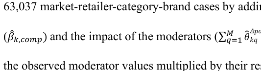

NOTE: contains mathematical notation; text above is the PDF text layer and symbols may be mis-extracted. Image shows the original.

**equation / math rendering (image)**

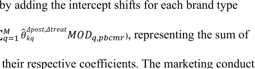

NOTE: contains mathematical notation; text above is the PDF text layer and symbols may be mis-extracted. Image shows the original.

the observed moderator values multiplied by their respective coefficients. The marketing conduct

**equation / math rendering (image)**

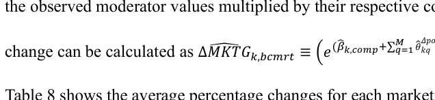

NOTE: contains mathematical notation; text above is the PDF text layer and symbols may be mis-extracted. Image shows the original.

**equation / math rendering (image)**

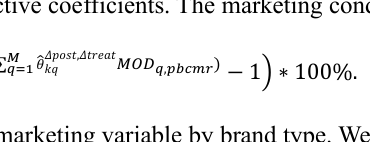

NOTE: contains mathematical notation; text above is the PDF text layer and symbols may be mis-extracted. Image shows the original.

Table 8 shows the average percentage changes for each marketing variable by brand type. We

observe the strongest average percentage lifts for regular price (especially for sister brands),

followed by feature advertising and distribution.

**Table 8. Net Marketing Conduct Changes by Brand Type**

| Brand Type Cases | Rival National Brand SisterBrand PrivateLabel 50663 4099 8275 , , , | Overall 63037 , |
| --- | --- | --- |
| PromotionPrice FeatureAdvertising RegularPrice LineLength Distribution | 05% 14% 01% -. -. -. 192% 216% 421% . . . 244% 290% 137% . . . 50% 64% 38% -. . -. 42% 59% 49% . . . | 05% -. 223% . 233% . 41% -. 44% . |

NOTE: table converted from PDF layout to HTML text; cell boundaries are reconstructed. See PDF if exact alignment matters.

Page 36

#### *Net Revenue Effect*

To establish the economic significance of marketing mix adjustments after a brand

deletion, we calculate the additional revenue these adjustments generate compared to the

baseline revenue change brands would experience without any marketing adjustments. To take

the brand-type specific moderator values into account, we calculate the baseline effect, which is

the brand-type specific gain due to the brand deletion (𝛽𝛽̂𝑐𝑐𝑐𝑐𝑐𝑐𝑐𝑐 in Equation 1) plus the treatment

**equation / math rendering (image)**

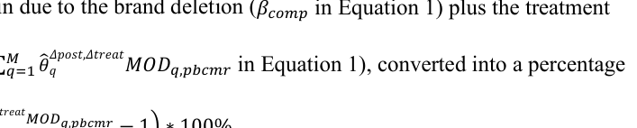

NOTE: contains mathematical notation; text above is the PDF text layer and symbols may be mis-extracted. Image shows the original.

**equation / math rendering (image)**

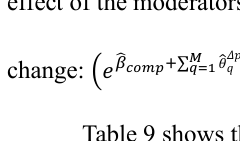

NOTE: contains mathematical notation; text above is the PDF text layer and symbols may be mis-extracted. Image shows the original.

**equation / math rendering (image)**

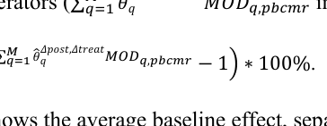

NOTE: contains mathematical notation; text above is the PDF text layer and symbols may be mis-extracted. Image shows the original.

Table 9 shows the average baseline effect, separately for each competitor brand type

(rival national brand, sister brand, and private label). We observe a .74% baseline revenue

increase for rival national brands, a .51% increase for sister brands, and a 2.28% increase for

private labels when not accounting for marketing conduct. Table 9 also shows the marketing

conduct impact, which is the percentage revenue change due to marketing efforts after the brand

deletion, calculated as the brand-type specific marketing elasticity (𝛾𝛾ො𝑐𝑐𝑐𝑐𝑐𝑐𝑐𝑐,𝑘𝑘 from Equation 1) times

**Table 9. Net Revenue Changes by Competitor Brand Type**

| Brand Type Cases | Rival National Brand SisterBrand PrivateLabel 50663 4099 8275 , , , | Overall 63037 , |
| --- | --- | --- |
| Baselineeffect PromotionPrice FeatureAdvertising RegularPrice Linelength Distribution | 74% 51% 228% . . . 09% 23% 01% . . . 07% 08% 09% . . . 12% 74% 25% -. -. -. 63% 84% 45% -. . -. 123% 183% 177% . . . | 93% . 09% . 07% . 18% -. 51% -. 134% . |
| Overall | 136% 277% 345% . . . | 173% . |

NOTE: table converted from PDF layout to HTML text; cell boundaries are reconstructed. See PDF if exact alignment matters.

Page 37

Table 9 shows that the marketing conduct impact in the wake of a brand deletion is

substantial. For sister brands, the observed increase in distribution adds 1.83% to revenue, while

the line length adds .84%, which helps to boost the smaller baseline effect of .51%, leading to an

overall revenue gain of 2.77% due to the brand deletion. Rival national brands manage to

roughly double their baseline gain (+.74%) through marketing conduct (+.63%) to a total

revenue gain of 1.36%, primarily through a distribution gain (+1.23%). Starting with a

substantial baseline effect of +2.28%, some of the marketing conduct by private labels helps

them (distribution increase adds 1.77%; feature advertising .09%), but other marketing conduct

hurts: regular price hike reduces revenue by -.25%, line length reduction lowers revenue by -

.45%. Still, private labels gain 3.45% in revenue in the wake of the brand deletion.

Considering the sizable marketing impact results in Table 9, we conclude that competing

brands have considerable leverage to sway revenue gains their way through their marketing

conduct after a brand deletion.

#### *Net Revenue Implications for Brand Manufacturers*

Using the net revenue effects for each competing brand (see Table 9), we assess how

much sister brands gain after a brand deletion. For the manufacturer of both the sister brand and

the deleted brand, the key question is whether the sister brand’s gain covers a substantial share of

the deleted brand’s former revenue. In other words, can manufacturers succeed in “killing a

brand, keeping a customer” (Kumar 2003, p. 86)? Although manufacturers may attempt to

persuade customers to switch to sister brands in their brand portfolio, sister brands typically are

positioned to minimize overlap and target distinct customer segments. Thus, customers are

unlikely to view a sister brand as the most suitable alternative. Moreover, deleting a brand may

create knowledge gaps for the manufacturer about how to serve customers.

Page 38

To assess how a manufacturer’s category revenues change when it deletes a brand, we

calculate the cumulative revenue change across all remaining sister brands in the category for

each market-retailer pair and compare it to the deleted brand’s pretreatment revenue. The

difference reveals the net revenue effect for the manufacturer. If the change is equivalent to the

deleted brand’s revenue, it retains 100%; if the revenue change for sister brands is smaller

(larger), it retains less (more) than 100%. We then aggregate these results across all market-

retailer pairs with at least one sister brand (on average, 1.36 sister brands were active).

For example, Wisk, a Sun Products brand that was deleted from the “Detergents - Heavy

Duty – Liquid” category, earned $7.13M in annual national revenues in this category in our

sample (conditional on a sister brand being present). After deletion, its Sun Products–owned

sister brands gained $2.04M (on average, Wisk had with 3.79 sister brands), leading to a net

revenue loss of -$5.09M (=$2.04M–$7.13M). Thus, the manufacturer recouped 28.52% (=

[2.04/7.13]×100%) of the deleted brand’s revenues through its sister brands. As Web Appendix

M shows, across the 215 deleted brands with sister brands, manufacturers recoup on average

37.76% of deleted-brand revenue (the average deleted brand earned $485,799 per year per

market-retailer pair, and sister brands recouped $183,453), though variation is substantial.

#### *Results for Effect of Brand Deletion on Category Revenue*

Table 10 reports on Equation 3, showing that the category revenue reduces by a net 2.3%

(b=-.024, *p*<.001) in the wake of the focal brand’s deletion. The model controls for the revenue

effects of category-level regular price (b=.597, *p*<.001), feature advertising (b=.077, *p*<.001),

and line length (b=.682, *p*<.001).

Page 39

**Table 10. Results for Effect of Brand Deletion on Category Revenue**

| Variable | Est . | SE | p-val . |
| --- | --- | --- | --- |
| TreatxPost | 024 -. | 006 . | 000 . |
| Post | 009 . | 003 . | 009 . |
| CategoryPrice | 597 . | 074 . | 000 . |
| CategoryFeature | 077 . | 002 . | 000 . |
| CategoryLineLength | 682 . | 020 . | 000 . |
| ControlFunctionTerm |  |  |  |
| Cross-Section FE |  |  |  |
| TimeFE |  |  |  |

NOTE: table converted from PDF layout to HTML text; cell boundaries are reconstructed. See PDF if exact alignment matters.

We conduct several robustness checks to establish the sensitivity of our findings to

modeling decisions. We describe these robustness checks in greater detail in Web Appendix N,

where we also present detailed parameter estimates for the revenue model.

As a first robustness check, we assess the sensitivity of our revenue model results to the

beginning of the brand deletion, which is determined using a moving average, by setting set T0

(the beginning of the deletion) to two weeks before the week in our focal analyses and re-

estimating our models. Second, we account for the staggered timing of treatment by employing a

stacked DID approach. By carefully selecting control units that are never treated within the

treated unit’s timeframe, it avoids the bias that can arise in standard two-way fixed effects

models, which mix valid and invalid comparisons (i.e., later-vs-earlier treated) when treatments

are heterogeneous (Baker, Larcker, and Wang 2022; Goodman-Bacon 2021). As a robustness

check, we apply a two-stage DID approach (Gardner et al. 2024) that accounts for staggered

adoption. In the first stage, we remove group and time patterns using untreated observations to

create adjusted outcomes; in the second stage, we estimate treatment effects on these adjusted

values. This design eliminates problematic later-vs-earlier contrasts. Third, we construct

counterfactuals for each treated brand using highly correlated control units. Our main analysis

Page 40

requires an average correlation of 𝜌𝜌̅ > .80 revenue and marketing mix trajectories for the treated

and control brands, ensuring close comparability. In two robustness checks, we use higher

minimum average correlations of 𝜌𝜌̅ > .85 and 𝜌𝜌̅ > .90. Fourth, while our focal model uses

clustered errors at the retailer-category-deleted brand-competing brand level, we also implement

clustered standard errors at the panel (i.e., market-retailer-category-deleted brand-competing

brand) level as an alternative to account for autocorrelation only.

Fifth, we assess to what extent our results in the revenue model are driven by the

corrections for endogeneity. To this end, we estimate three additional versions of Equation 1:

without any control-function terms, with only the control-function term for the deletion decision,

and with only control-function terms for the marketing mix. Sixth, because brand deletions occur

at different times across markets and retailers, we exploit this staggered timing by using not-yet-

deleted cases as controls. To test whether timing matters, we compare early versus late deletions.

A relevant question is whether effects differ between early versus late brand deletion cases. To

investigate, we divide the sample into “Early deletion” cases (start date before the median) and

“Late deletion” cases (after the median) and add an interaction effect of treatment x post with an

indicator for Early deletion (base = Late deletion) in Equation 1. Seventh, it is conceivable that

the five marketing mix variables have interactive effects and that there are decreasing returns to

scale for line length. We added all 10 pairwise interactions to Equation 1, and separately added

the squared log line length.

We find the parameter estimates to be very similar to the focal estimates, with an average

correlation of .990 across robustness checks. We also note that the average proportion of

estimates that are different in terms of significance (i.e., p-value just below vs. above .1)

compared to the focal estimates (.06) is less than would be expected by chance (.1).

Page 41

#### **DISCUSSION**

Brand manufacturers regularly prune their brand portfolios by deleting brands from a

given product category. Despite the prevalence of brand deletions, their consequences are not

well understood. We therefore adopt an empirics-first approach and assess – based on 1,046

brand deletions across 384 categories affecting 63k market-retailer-category-brand combinations

– the effect of a brand’s deletion on competing brands that remain active in the category. In so

doing, we answer the four research questions introduced at the start.

First, we assess whether rival national brands, sister national brands, or private labels

benefit from a brand’s deletion. We find that – absent the impact of moderators and marketing

conduct – rival national brands and sister brands experience no loss or gain, while private labels

gain revenue in the wake of the brand deletion (Table 6; path A in Figure 1). When we add the

impact of the moderators (research question 2; Table 9; path B in Figure 1), the revenue effect

nuance to these insights, showing that competing brands gain more revenue when the competing

brand had higher price similarity with the deleted brand, when the deleted brand’s pre-deletion

market share is higher, and when the category is less concentrated.

Further nuance is added by considering research question 3 about the extent to which

competing brands change their marketing conduct after a brand deletion (path C in Figure 1).

After accounting for the impact of moderators on marketing conduct (path D in Figure 1), we

find that all brand types increase their regular price. However, because their price elasticity of

revenue is negative, they experience a drop in revenue due to this move. All brand types manage

to increase their distribution in the wake of the brand deletion, which, when combined with

strong distribution elasticities, leads to reasonably sizeable revenue gains of 1.23%-1.83% due to

Page 42

this form of marketing conduct across the three brand types. One surprising result is that only

sister brands increase their line length in the wake of the brand deletion (Table 8), which

(combined with a strong line length elasticity) generates an additional .84% revenue gain. A

plausible explanation is that sister brands may have access to brand deletion information earlier,

enabling them to plan line extensions in advance and thus react more quickly, preempting line

extensions by others. In addition, they may benefit from reallocated resources, as the budget

from the deleted brand can be used to support line length expansion.

Combining these insights allows us to address the final research question, which is how

competing brands fare overall after the brand deletion, taking into account the extent to which

they engage in marketing conduct changes (Table 9). We find that overall, private labels benefit

the most (+3.45% revenue), with sister brands in second place (+2.77%) and rival national

brands in third (+1.36%). Given that the vast majority of competing brands (80%) are rival

national brands, the overall average revenue gain is 1.73%. We do note there is a lot of

heterogeneity underlying these findings and a big role for marketing conduct, discussed next.

#### *Marketing Conduct Insights*

We document new insights with respect to brands’ marketing conduct (relative to the

control group) in the wake of a brand deletion, which we summarize in Table 11. We document

four types of patterns. One pattern is a *lost opportunity* where marketing effectiveness is strong,

but the marketing conduct change is minor, which we observe for price promotion for all brand

types. A second pattern is *spoiled arms*, where marketing conduct change is in the right direction,

but the effectiveness is weak, with feature advertising as a prime example, especially for private

labels. A third pattern is a *seized opportunity*, where marketing conduct is adjusted in the right

direction and the effectiveness is strong. The lift in distribution is a prime example for all three

Page 43

brand types, as is the lift in line length for sister brands. The final and worst pattern is a *self-*

*inflicted loss*, where an effective marketing variable is adjusted in the opposite direction from

what would benefit revenue. The regular price hikes across all competitor brand types is one

example of a self-inflicted loss, as are line length cuts by rival national brands and private labels.

**Table 11. Insights on How Competing Brands Can Capitalize on Brand Deletions**

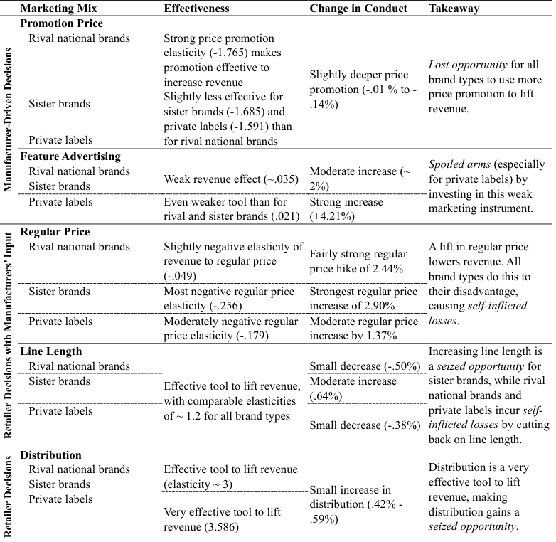

NOTE: complex table shown as an image of the PDF; the text below is a rough machine extraction and may be mis-aligned.

**extracted text (unreliable layout)**

; MarketingMix ; Effectiveness ; ChangeinConduct ; Takeaway | ; PromotionPrice ; ; ; | ; Rivalnationalbrands ; Strongpricepromotion ; ; | Manufacturer-Driven Decisions ; Sisterbrands Privatelabels FeatureAdvertising Rivalnationalbrands Sisterbrands Privatelabels ; elasticity ( -1 .765) makes promotioneffectiveto increaserevenue Slightlylesseffectivefor sister brands ( -1 .685) and private labels ( -1 .591) than forrivalnationalbrands Weak revenue effect ( ~.035) Evenweakertoolthanfor rivalandsisterbrands(021) . ; Slightlydeeperprice promotion ( -.01 % to - 14%) . Moderateincrease( ~ 2%) Strongincrease (+421%) . ; Lostopportunityforall brandtypestousemore pricepromotiontolift revenue . Spoiledarms(especially forprivatelabels)by investinginthisweak marketinginstrument . | RetailerDecisionswithManufacturers’Input ; RegularPrice Rivalnationalbrands Sisterbrands Privatelabels LineLength Rivalnationalbrands Sisterbrands Privatelabels ; Slightlynegativeelasticityof revenuetoregularprice ( 049) -. Mostnegativeregularprice elasticity ( -.256) Moderatelynegativeregular price elasticity ( -.179) Effectivetooltoliftrevenue , withcomparableelasticities of ~ 1 .2 for all brand types ; Fairlystrongregular pricehikeof244% . Strongestregularprice increaseof290% . Moderateregularprice increaseby137% . Small decrease ( -.50%) Moderateincrease (64%) . Small decrease ( -.38%) ; Aliftinregularprice lowersrevenue All . brandtypesdothisto theirdisadvantage , causing self -inflicted losses . Increasinglinelengthis aseizedopportunityfor sisterbrands whilerival , nationalbrandsand private labels incur self - inflictedlossesbycutting backonlinelength . | RetailerDecisions ; Distribution Rivalnationalbrands Sisterbrands Privatelabels ; Effectivetooltoliftrevenue (elasticity~3) Veryeffectivetooltolift revenue(3586) . ; Smallincreasein distribution ( .42% - 59%) . ; Distributionisavery effectivetooltolift revenue making , distributiongainsa seizedopportunity .

Page 44

#### *Managerial Implications*

Marketing literature is replete with advice on how to build brands (e.g., Ataman, Mela,

and van Heerde 2008). In contrast, there is relatively little advice about how to deal with brand

deletions. Doing nothing is a reasonable course of action for private labels (revenue +2.28%), but

much less successful for rival national brands (+.74%) and particularly sister brands (+.51%). We

recommend a more active response, and we highlight the promise of active marketing conduct,

designed to capitalize on the opportunity created by a brand deletion (see also Table 9). One

obvious caveat to the managerial implications presented next is that rival and sister brands may

have different degrees of agency over marketing decisions. That is, while promotion price and

feature advertising are primarily manufacturer-driven, regular price and line length are co-

decided with retailers, while distribution is governed by retailers. We also note that our

recommendations focus on revenue (rather than profit) implications of marketing conduct, as we

lack data on the cost of changes in marketing and on profit margins.

*Rival national brands*

For rival national brands, deploying price promotion is a feasible, effective, yet

underutilized form of marketing conduct in the wake of a brand deletion (see Table 11). Even if

price promotions might threaten to undermine a premium brand image or brand equity in the

long term (Jedidi, Mela, and Gupta 1999), they can strongly boost brand revenue in the short

term to seize customers from the deleted brand. Feature advertising, in contrast, does not

necessarily need to be increased given its relatively weak effectiveness.

When rival national brands decide with retailers on regular price in the wake of the brand

deletion, one important input into this decision is the relatively inelastic price response (-.049) of

the revenue of rival national brands. In a way, the inelastic response justifies the fairly strong

Page 45

regular price rise we document for these brands (+2.44%). As for line length, rival national

brands should point out to retailers that the strong line length elasticities (around 1.3) warrant

extending the brand’s line length carried by the retailer, which is opposite to the shrinkage (-

.50%) that we document empirically. To convince retailers to carry the brand in more stores, rival

national brand manufacturers should point out the strong distribution elasticity (2.942).

*Sister brands*

The recommendations for sister brands are largely parallel to those for rival national

brands. They should also offer more price promotions (without a need for feature advertising)

and point to strong line length and distribution elasticities to convince retailers to carry their

SKUs in more stores. One diverging implication emerges for regular price: given the relatively

strong elasticity of revenue to regular price for sister brands (-.256), the observed strong increase

in regular price (+2.90%) caused self-inflicted revenue losses. Mitigating regular price increases

(or even reducing regular price after a brand deletion) is recommended for sister brands.

Looking at the bigger picture, for manufacturers that maintain multiple brands in a

category and plan to delete one, our findings provide cold comfort. Sister brands recoup less than

40% of the revenue lost due to the brand deletion on average. Of course, other considerations

(unobservable to us) might prompt manufacturers to delete a brand from a category (e.g.,

efficiency gains in brand management, supply issues), but from an overall revenue perspective,

we suggest caution.

*Private labels*

Our findings are especially encouraging for private labels. Private labels gain, on

average, 2.28% revenue from a brand deletion if they keep their marketing mix unchanged.

Moreover, private labels have full control over all marketing variables as these brands are owned

Page 46

by retailers. Capitalizing on their strong distribution elasticity (3.586), private labels should

increase their distribution (if it is not at 100% yet), seizing the shelf space left vacant by the

deleted brand. Private labels’ second and third strongest elasticities are for price promotion (-

1.591) and line length (1.190), making price promotion and line length extension effective (yet

currently underutilized) ways to attract customers in the wake of the brand deletion. Given

feature advertising’s relatively weak elasticity (.021), we again suggest caution. Although feature

advertising is relatively easy to deploy as a marketing tactic (and private labels eagerly do so),

we find it is not an effective way to gain revenue after brand deletion.

Overall, while private label marketing effectiveness is somewhat weaker on average than

sister brands and rival national brands (except for distribution, where they dominate national

brands), they can gain a lot of ground by making judicious adjustments to their most powerful

marketing variables, such as distribution, price promotion, and line length. Thus, while an

inactive stance in response to a brand deletion will bring some benefits to private labels, an

active stance (i.e., increasing marketing support to capitalize on the deletion) can potentially

produce strong payoffs.

#### *Limitations and Further Research*

While we shed some first light on the consequences of brand deletions, we suggest that

follow-up research could investigate their antecedents (which is beyond the scope of this study).

A variety of possible motives might drive manufacturers to delete brands from the market,

including economic (lack of profitability), branding (creating opportunities for sister brand

growth), supply (difficulty of sourcing inputs), knowledge (lack of in-firm category expertise), or

brand consistency (deleted brand does not fit the rest of the brand portfolio) motives.

Investigating the prevalence and strength of these different motives for brand deletions can shed

Page 47

additional light on this under-researched domain. The decision to delete a brand has potentially

many antecedents, some of which are observable (e.g., the presence of sister brands) but others

are unobservable (change in focus, anticipation of competitors).

Unfortunately, we lack advertising data for all markets, retailers, categories, brands, and

time periods. However, recent research studying U.S. grocery products reports very small

advertising elasticities (.0098-.0261; Shapiro, Hitsch, and Tuchman 2021), suggesting minimal

advertising effects. We also note that national advertising influences both treated and control

units, so even with such data, isolating a treatment effect would not be feasible.

Furthermore, we document the revenue consequences of brand deletions using retail

scanner data, highlighting a promising avenue for examining how brand pruning affects investor

and firm value. In the introduction, we reference large-scale pruning initiatives by firms such as

P&G (100 brands deleted) and Coca-Cola (200 brands). Future research could investigate how

these strategies influence firm value (e.g., abnormal returns or Tobin’s Q). Such research could

quantify both the magnitude and mechanisms of these effects – for instance, whether cost savings

offset potential revenue losses.

Our sample frame covers each market’s top 10 competing brands and each market’s top 3

retailers to ensure enough economic substance. Given this decision rule, we had to omit smaller

competing brands that are not among the 10 leading competing brands in the market, but may be

a top 10 competing brand within a given retailer.

In summary, we believe this study makes some meaningful headway in understanding the

consequences of brand deletions and how competing brands can seize the opportunities by

engaging with their marketing mix. We further hope this study stimulates new research into this

important yet underexplored marketing domain.

Page 48

#### **REFERENCES**

Abadie, Alberto (2021), “Using Synthetic Controls: Feasibility, Data Requirements, and

Methodological Aspects,” *Journal of Economic Literature*, 59 (2), 391-425. Angrist, Joshua D. (2014), “The Perils of Peer Effects,” *Labour Economics*, 30, 98-108. Argouslidis, Paraskevas C. and George Baltas (2007), “Structure in Product Line Management:

The Role of Formalization in Service Elimination Decisions,” *Journal of the Academy of Marketing Science*, 35, 475-91. Ataman, M. Berk, Carl F. Mela, and Harald J. van Heerde (2008), “Building Brands,” *Marketing*

*Science*, 27 (6), 1036-54. Baker, Andrew C., David F. Larcker, and Charles C. Y. Wang (2022), “How Much Should We

Trust Staggered Difference-in-Differences Estimates?,” *Journal of Financial Economics*, 144 (2), 370-95. Bijmolt, Tammo H. A., Harald J. van Heerde, and Rik Pieters (2005), “New Empirical

Generalizations on the Determinants of Price Elasticity,” *Journal of Marketing Research*, 42 (2), 141-56. Blattberg, Robert C. and Kenneth J. Wisniewski (1989), “Price-Induced Patterns of

Competition,” *Marketing Science*, 8 (4), 291-309. Boatwright, Peter and Joseph C. Nunes (2001), “Reducing Assortment: An Attribute-Based

Approach,” *Journal of Marketing*, 65 (3), 50-63. Bollinger, Bryan and Steven E. Sexton (2023), “Local Excise Taxes, Sticky Prices, and

Spillovers: Evidence from Berkeley’s Soda Tax,” *Quantitative Marketing and Economics*, 21, 281-331. Borle, Sharad, Peter Boatwright, Joseph B. Kadane, Joseph C. Nunes, and Shmueli Galit (2005),

“The Effect of Product Assortment Changes on Customer Retention,” *Marketing Science*, 24 (4), 616-22. Breugelmans, Els, Els Gijsbrechts, and Katia Campo (2018), “Product Unavailability,” in

*Handbook of Research on Retailing*, Katrijn Gielens and Els Gijsbrechts, eds.: Edward Elgar Publishing, 203-19. Broniarczyk, Susan M., Wayne D. Hoyer, and Leigh McAlister (1998), “Consumers’ Perceptions

of the Assortment Offered in a Grocery Category: The Impact of Item Reduction,” *Journal of Marketing Research*, 35 (2), 166-76. Campo, Katia, Els Gijsbrechts, and Patricia Nisol (2000), “Towards Understanding Consumer

Response to Stock-Outs,” *Journal of Retailing*, 76 (2), 219-42. ---- (2003), “The Impact of Retailer Stockouts on Whether, How Much, and What to Buy,”

*International Journal of Research in Marketing*, 20 (3), 273-86. ---- (2004), “Dynamics in Consumer Response to Product Unavailability: Do Stock-out

Reactions Signal Response to Permanent Assortment Reductions?,” *Journal of Business Research*, 57 (8), 834-43. Cleeren, Kathleen, Harald J. van Heerde, and Marnik G. Dekimpe (2013), “Rising from the

Ashes: How Brands and Categories Can Overcome Product-Harm Crises,” *Journal of Marketing*, 77 (2), 58-77. Crespo, Francisco (2018), “Success, Failure, and Zombie Hunting,” (accessed May 30, 2025),

[available at https://web.archive.org/web/20180725175725/https://www.cocacolacompany.com/stories/success--failure-and-zombie-hunting].

Page 49

Datta, Hannes, Kusum L. Ailawadi, and Harald J. van Heerde (2017), “Does Consumer-Based

Brand Equity Manifest Itself in Sales-Based Brand Equity and in Marketing Mix Effectiveness?,” *Journal of Marketing*, 81 (3), 1-20. Datta, Hannes, Harald J. van Heerde, Marnik G. Dekimpe, and Jan-Benedict E.M. Steenkamp

(2022), “Cross-National Differences in Market Response: Line-Length, Price, and Distribution Elasticities in 14 Indo-Pacific Rim Economies,” *Journal of Marketing Research*, 59 (2), 251-70. De Clerck, Sigrid, Els Gijsbrechts, Jan-Benedict E. M. Steenkamp, and Marnik G. Dekimpe

(2001), “The Impact of Assortment Reductions and Extensions on Category Sales,” working paper: Catholic University Leuven. Drèze, Xavier, Stephen J. Hoch, and Mary E. Purk (1994), “Shelf Management and Space

Elasticity,” *Journal of Retailing*, 70 (4), 301-26. Dukes, Anthony J., Tansev Geylani, and Kannan Srinivasan (2009), “Strategic Assortment

Reduction by a Dominant Retailer,” *Marketing Science*, 28 (2), 309-19. Emmelhainz, Margaret A., James R. Stock, and Larry W. Emmelhainz (1991), “Consumer

Responses to Retail Stock-Outs,” *Journal of Retailing*, 67 (2), 138. Farris, Paul, James Olver, and Cornelis De Kluyver (1989), “The Relationship between

Distribution and Market Share,” *Marketing Science*, 8 (2), 107-28. Fitzsimons, Gavan J. (2000), “Consumer Response to Stockouts,” *Journal of Consumer*

*Research*, 27 (2), 249-66. Fok, Dennis and Philip Hans Franses (2004), “Analyzing the Effects of a Brand Introduction on

Competitive Structure Using a Market Share Attraction Model,” *International Journal of Research in Marketing*, 21 (2), 159-77. Gardner, John, Neil Thakral, Linh T Tô, and Luther Yap (2024), “Two-Stage Differences in

Differences,” University of Mississippi. Golder, Peter N., Marnik Dekimpe, Jake T. An, Harald J. van Heerde, Darren Kim, and Joseph

W. Alba (2023), “Learning from Data: An Empirics-First Approach to Relevant Knowledge Generation,” *Journal of Marketing*, 87 (3), 319–36. Goodman-Bacon, Andrew (2021), “Difference-in-Differences with Variation in Treatment

Timing,” *Journal of Econometrics*, 225 (2), 254-77. Gourville, John T. and Dilip Soman (2005), “Overchoice and Assortment Type: When and Why

Variety Backfires,” *Marketing Science*, 24 (3), 382-95. Harness, David R. and Norman E. Marr (2001), “Strategies for Eliminating a Financial Services

Product,” *Journal of Product and Brand Management*, 10 (7), 423-38. Hermans, Marleen, Néomie Raassens, and Kathleen Cleeren (2024), “What Is the Impact of a

Conflict Delisting on Firm Value? An Investigation of the Role of Conflict and Firm Characteristics,” *Journal of the Academy of Marketing Science*, 52 (1), 240-59. Homburg, Christian, Andreas Fürst, and Jana-Kristin Prigge (2010), “A Customer Perspective on

Product Eliminations: How the Removal of Products Affects Customers and Business Relationships,” *Journal of the Academy of Marketing Science*, 38, 531-49. Hwang, Minha, Bart J. Bronnenberg, and Raphael Thomadsen (2010), “An Empirical Analysis of

Assortment Similarities across US Supermarkets,” *Marketing Science*, 29 (5), 858-79. Jedidi, Kamel, Carl F. Mela, and Sunil Gupta (1999), “Managing Advertising and Promotion for

Long-Run Profitability,” *Marketing Science*, 18 (1), 1-22. Kalyanam, Kirthi, Sharad Borle, and Peter Boatwright (2007), “Deconstructing Each Item’s

Category Contribution,” *Marketing Science*, 26 (3), 327-41.

Page 50

Keller, Kristopher O. and Jonne Y. Guyt (2023), “A War on Sugar? Effects of Reduced Sugar

Content and Package Size in the Soda Category,” *Journal of Marketing*, 87 (5), 698-718. ---- (2025), “Consequences of Bottle Bills: How Bottle Deposit Return Schemes Affect Retail

Prices and Lead Consumers to Larger Package Sizes,” *Journal of Marketing*, forthcoming. Kumar, Nirmalya (2003), “Kill a Brand, Keep a Customer,” *Harvard Business Review*, 81 (12),

86. Li, Kathleen T. and Christophe Van den Bulte (2023), “Augmented Difference-in-Differences,”

*Marketing Science*, 42 (4), 746-67. Ma, Yu, Kusum L. Ailawadi, Dinesh K. Gauri, and Dhruv Grewal (2011), “An Empirical

Investigation of the Impact of Gasoline Prices on Grocery Shopping Behavior,” *Journal of Marketing*, 75 (2), 18-35. Morning Brew (2020), “Coca-Cola Cuts "Zombie Brands" from Its Portfolio,” (accessed May 28,

2025), [available at https://www.morningbrew.com/stories/2020/10/08/cocacola-cuts-zombiebrands-portfolio]. Oppewal, Harmen and Kitty Koelemeijer (2005), “More Choice Is Better: Effects of Assortment

Size and Composition on Assortment Evaluation,” *International Journal of Research in Marketing*, 22 (1), 45-60. Papies, Dominik, Peter Ebbes, and Harald J. van Heerde (2017), “Addressing Endogeneity in

Marketing Models,” in *Advanced Methods for Modeling Markets*, Peter S.H. Leeflang and Jaap E. Wieringa and Tammo H. A. Bijmolt and Koen H. Pauwels, eds. New York City, NY: Springer, 581-627. Peckham, James O. (1963), “The Consumer Speaks,” *Journal of Marketing*, 27 (4), 21-26. Rose, Charlie (2025), “Scaling Smart: Why a Unified Brand Beats a Portfolio of Many,”

(accessed May 29, 2025), [available at https://www.warc.com/newsandopinion/opinion/scaling-smart-why-a-unified-brand-beats-aportfolio-of-many/en-gb/7014]. Schary, Philip B. and Martin Christopher (1979), “Anatomy of a Stock-Out,” *Journal of*

*Retailing*, 55 (2), 59-70. Shapiro, Bradley T., Günter J. Hitsch, and Anna E. Tuchman (2021), “Tv Advertising

Effectiveness and Profitability: Generalizable Results from 288 Brands,” *Econometrica*, 89 (4), 1855-79. Shi, Huanhuan, Rajdeep Grewal, and Hari Sridhar (2021), “Organizational Herding in

Advertising Spending Disclosures: Evidence and Mechanisms,” *Journal of Marketing Research*, 58 (3), 515-38. Sivakumar, K. and S. P. Raj (1997), “Quality Tier Competition: How Price Change Influences

Brand Choice and Category Choice,” *Journal of Marketing*, 71 (3), 71-84. Sloot, Laurens M, Peter C. Verhoef, and Philip Hans Franses (2005), “The Impact of Brand

Equity and the Hedonic Level of Products on Consumer Stock-out Reactions,” *Journal of Retailing*, 81 (1), 15-34. Sloot, Laurens M., Dennis Fok, and Peter C. Verhoef (2006), “The Short-and Long-Term Impact

of an Assortment Reduction on Category Sales,” *Journal of Marketing Research*, 43 (4), 536- 48. Sloot, Laurens M. and Peter C. Verhoef (2008), “The Impact of Brand Delisting on Store

Switching and Brand Switching Intentions,” *Journal of Retailing*, 84 (3), 281-96. Sridhar, Shrihari, Frank Germann, Charles Kang, and Rajdeep Grewal (2016), “Relating Online,

Regional, and National Advertising to Firm Value,” *Journal of Marketing*, 80 (4), 39-55.

Page 51

Tan, Lay Peng and Jack Cadeaux (2011), “Brand and Stock-Keeping-Unit (SKU) Assortments,

Assortment Changes and Category Sales,” *The International Review of Retail, Distribution and Consumer Research*, 21 (2), 161-85. Unilever (2025), “Ren Closure,” [available at https://www.unilever.com/news/press-and-

media/press-releases/2025/ren-closure/]. Vafainia, Saeid, Els Breugelmans, Sara Van Der Maelen, and Kathleen Cleeren (2025),

“Depicting a Holistic Picture of the Impact of Conflict Delistings: Consequences Beyond the Involved Brands, Retailer and Categories,” *Journal of Retailing*, forthcoming. Van der Maelen, Sara, Els Breugelmans, and Kathleen Cleeren (2017), “The Clash of the Titans:

On Retailer and Manufacturer Vulnerability in Conflict Delistings,” *Journal of Marketing*, 81 (1), 118-35. van Heerde, Harald J., Maarten J. Gijsenberg, Marnik G. Dekimpe, and Jan-Benedict E.M.

Steenkamp (2013), “Price and Advertising Effectiveness over the Business Cycle,” *Journal of Marketing Research*, 50 (2), 177-93. Verbeke, Willem, Paul Farris, and Roy Thurik (1998), “Consumer Response to the Preferred

Brand out‐of‐Stock Situation,” *European Journal of Marketing*, 32 (11/12), 1008-28. Verhoef, Peter C. and Laurens M. Sloot (2009), “Out-of-Stock: Reactions, Antecedents,

Management Solutions, and a Future Perspective,” in *Retailing in the 21st Century: Current and Future Trends*: Springer, 285-99. Wall Street Journal (2014), “P&G to Shed More Than Half Its Brands,” (accessed September 19,

2022), [available at https://online.wsj.com/articles/procter-gamble-posts-higher-pro]. ---- (2020), “Coca-Cola to Discontinue Zico, May Drop Coke Life,” (accessed October 2, 2022),

[available at https://www.wsj.com/articles/coca-cola-to-discontinue-zico-may-drop-coke-life- 11601838341]. Walter, Clyde K. and John R. Grabner (1975), “Stockout Cost Models: Empirical Tests in a

Retail Situation,” *Journal of Marketing*, 39 (3), 56-60. Wooldridge, Jeffrey M. (2010), *Econometric Analysis of Cross Section and Panel Data*.

Cambridge, MA: MIT press. Zhang, Jie and Aradhna Krishna (2007), “Brand-Level Effects of Stockkeeping Unit

Reductions,” *Journal of Marketing Research*, 44 (4), 545-59. Zinn, Walter and Peter C. Liu (2001), “Consumer Response to Retail Stockouts,” *Journal of*

*Business Logistics*, 22 (1), 49-71.

Page 52

W1

#### **Filling the Void: How Competing Brands Can Capitalize on a Brand Deletion**

#### *Table of Contents*

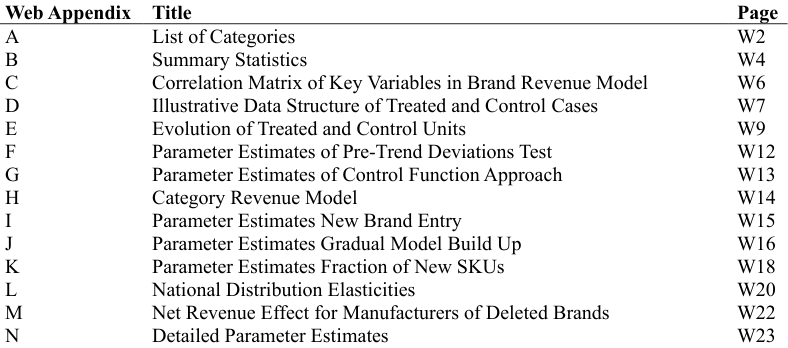

NOTE: complex table shown as an image of the PDF; the text below is a rough machine extraction and may be mis-aligned.

**extracted text (unreliable layout)**

WebAppendix ; Title ; Page | A B C D E F G H I J K L M N ; List ofCategories SummaryStatistics CorrelationMatrix ofKeyVariables inBrandRevenueModel IllustrativeDataStructureofTreatedandControl Cases EvolutionofTreatedand Control Units ParameterEstimates ofPre-TrendDeviationsTest ParameterEstimates ofControl FunctionApproach CategoryRevenueModel ParameterEstimates NewBrandEntry ParameterEstimates Gradual Model BuildUp ParameterEstimates FractionofNewSKUs National DistributionElasticities Net RevenueEffect for Manufacturers of DeletedBrands DetailedParameterEstimates ; W2 W4 W6 W7 W9 W12 W13 W14 W15 W16 W18 W20 W22 W23

Page 53

W2

#### **Web Appendix A: List of Categories**

**Group Description Module Description (Category)** Baby Food Baby Food - Strained Baby Food Baby Food - Junior Baby Needs Baby Accessory Baby Needs Nursing Accessories Baby Needs Baby Care Products-Bath Baked Goods-Frozen Bakery - Biscuits/Rolls/Muffins - Frozen Baked Goods-Frozen Bakery-Bread-Frozen Baked Goods-Frozen Bakery - Dessert Cakes - Frozen Baking Mixes Mixes - Brownies Baking Mixes Mixes-Dessert-Misc. Baking Mixes Mixes-Rolls & Biscuits Baking Mixes Mixes - Pancake Baking Supplies Croutons Baking Supplies Cake Decorations & Icing Baking Supplies Coconut Baking Supplies Cocoa Batteries And Flashlights Batteries Beer Beer Beer Light Beer (Low Calorie/Alcohol) Beer Ale Books And Magazines Magazines Selected Titles Bread And Baked Goods Bakery - Bread - Fresh Bread And Baked Goods Bakery-Buns-Fresh Bread And Baked Goods Bakery-Rolls-Fresh Bread And Baked Goods Bakery-Muffins-Fresh Bread And Baked Goods Bakery-Cakes-Fresh Bread And Baked Goods Bakery-Breakfast Cakes/Sweet Rolls-Fresh Bread And Baked Goods Bakery-Doughnuts-Fresh Bread And Baked Goods Bakery-Pies-Fresh Bread And Baked Goods Bakery-Bagels-Fresh Bread And Baked Goods Bakery - Remaining - Fresh Bread And Baked Goods Bakery-Cheesecake-Fresh Breakfast Food Toaster Pastries Breakfast Food Granola & Yogurt Bars Breakfast Food Breakfast Bars Breakfast Foods-Frozen Frozen/Refrigerated Breakfasts Breakfast Foods-Frozen Frozen Waffles & Pancakes & French Toast Butter And Margarine Margarine And Spreads Candy Breath Sweeteners Candy Candy-Chocolate-Miniatures Candy Candy-Chocolate Candy Candy-Chocolate-Special Candy Candy-Non-Chocolate Candy Candy-Lollipops Candy Candy-Dietetic - Non-Chocolate Candy Candy-Dietetic - Chocolate Carbonated Beverages Soft Drinks - Carbonated Carbonated Beverages Soft Drinks - Low Calorie Cereal Cereal - Ready To Eat Cereal Cereal - Granola & Natural Types Cereal Cereal - Hot Charcoal, Logs, Accessories Charcoal Cheese Cheese - Natural - Mozzarella Cheese Cheese - Natural - Remaining Cheese Cheese - Natural - American Cheddar Cheese Cheese - Grated Cheese Cheese - Processed - Snack Cheese Cheese-Processed Slices-American Cheese Cheese-Natural-Swiss Cheese Cheese - Specialty/Imported Cheese Cheese - Natural - Variety Pack Cheese Cheese - Shredded Cheese Cheese - Processed - Cream Cheese Coffee Ground And Whole Bean Coffee Coffee Coffee - Soluble Flavored Coffee Coffee - Liquid Condiments, Gravies, And Sauces Barbecue Sauces Condiments, Gravies, And Sauces Spaghetti/Marinara Sauce Condiments, Gravies, And Sauces Cooking Sauce Condiments, Gravies, And Sauces Sauces - Miscellaneous - Shelf Stable Condiments, Gravies, And Sauces Gravy - Canned Condiments, Gravies, And Sauces Sauces - Dipping Condiments, Gravies, And Sauces Sauce Mix - Taco Condiments, Gravies, And Sauces Mustard Cookies Cookies Cookware Cookware Product Cosmetics Cosmetics-Lipsticks Cosmetics Cosmetics-Eyebrow & Eye Liner Cosmetics Cosmetics-Nail Polish Cosmetics Cosmetics-Mascara Cosmetics Cosmetic Kits Cosmetics Cosmetics-Remaining Cosmetics Cosmetics-Foundation-Cream And Powder Cosmetics Cosmetics - Concealers Cot Cheese, Sour Cream, Toppings Dairy - Sour Cream - Refrigerated & Canned Cot Cheese, Sour Cream, Toppings Cheese - Cottage Cough And Cold Remedies Nasal Product Internal Cough And Cold Remedies Cold Remedies - Adult Cough And Cold Remedies Cough Syrups & Tablets Cough And Cold Remedies Sinus Remedies Crackers Crackers - Cheese Crackers Wafers & Toast & Bread Sticks Crackers Crackers - Flavored Snack Deodorant Deodorants - Personal Deodorant Deodorants - Cologne Type Desserts, Gelatins, Syrup Syrup-Specialty Desserts, Gelatins, Syrup Toppings-Liquid & Dry Desserts, Gelatins, Syrup Desserts - Rts Single Servings - Canned Desserts/Fruits/Toppings-Frozen Frozen Fruits Desserts/Fruits/Toppings-Frozen Frozen Desserts Detergents Detergents-Packaged Detergents Detergents - Light Duty Detergents Detergents - Heavy Duty - Liquid Detergents Automatic Dishwasher Compounds Diet Aids Dieting Aids-Complete Nutritional Disposable Diapers Disposable Diapers Dressings/Salads/Prep Foods-Deli Pasta - Refrigerated Dressings/Salads/Prep Foods-Deli Precut Fresh Salad Mix Dressings/Salads/Prep Foods-Deli Fruit-Refrigerated Dressings/Salads/Prep Foods-Deli Fruit Salads-Refrigerated Dressings/Salads/Prep Foods-Deli Remaining-Ready Made Salads Dressings/Salads/Prep Foods-Deli Meat & Sandwich Spreads-Refrigerated

**Group Description Module Description (Category)** Dressings/Salads/Prep Foods-Deli Entrees-Refrigerated Dressings/Salads/Prep Foods-Deli Sandwiches-Refrigerated/Frozen Dressings/Salads/Prep Foods-Deli Combination Lunches Dressings/Salads/Prep Foods-Deli Pizza-Refrigerated Eggs Eggs-Fresh Electronics, Records, Tapes Ink Jet And Toner Cartridge Electronics, Records, Tapes Disk Diskette And Data Cartridge Electronics, Records, Tapes Printers Ethnic Haba Hair Preparations-Ethnic Feminine Hygiene Feminine Hygiene-Miscellaneous First Aid First Aid - Treatments First Aid Adhesive Bandages - Liquid - Powder - Paste First Aid First Aid - Ice And Heat Pack Floral, Gardening Lawn And Soil Fertilizer And Treatment Fragrances - Women Cologne & Perfume-Women's Fragrances - Women Children's Cologne & Gift Sets Fresh Meat Fresh Meat Fresh Produce Fresh Apples Fresh Produce Fresh Herbs Fresh Produce Fresh Mushrooms Fresh Produce Fresh Carrots Fresh Produce Fresh Celery Fresh Produce Fresh Fruit-Remaining Fresh Produce Fresh Vegetables-Remaining Fresh Produce Fresh Onions Fresh Produce Fresh Potatoes Fresh Produce Fresh Strawberries Fresh Produce Fresh Tomatoes Fresheners And Deodorizers Air/Specialty Freshners - Aerosol Spray & Pump Fresheners And Deodorizers Air/Specialty Fresheners - Remaining Fruit - Dried Fruit-Dried And Snacks Glassware, Tableware Candle And Candle In Holder Glassware, Tableware Drinkware Container Set Grooming Aids Hair Care And Fashion Accessory Grooming Aids Cosmetics - Applicator Brushes Grt Cards/Party Needs/Novelties Candle Holder And Accessory Gum Gum-Bubble Gum Gum-Chewing-Sugarfree Hair Care Shampoo-Aerosol/ Liquid/ Lotion/ Powder Hair Care Creme Rinses & Conditioners Hair Care Wave Setting Products Hair Care Hair Spray - Women's Hair Care Hair Coloring - Women's Hair Care Hair Preparations - Other Than Men's Hardware, Tools Storage And Space Management Hardware, Tools Trash And Recycling Bin Hardware, Tools Buckets & Pails Household Cleaners Cleaners - Disinfectants Household Cleaners Cleaners - Non-Disinfectant Household Cleaners Cleaners - Bathroom Household Supplies Bathroom Accessory Household Supplies Scouring Pads Household Supplies Brushes-Bathroom Household Supplies Thermometers-Household/Outdoor Household Supplies Water Filtration Storage Container Household Supplies Cloth-Polishing/Cleaning Household Supplies Brooms/ Mops & Wax Applicators Household Supplies Dustpans Housewares, Appliances Household Appliance Accessories Housewares, Appliances Garment Steamer And Iron Appliance Housewares, Appliances Coffee And Tea Maker Appliance Housewares, Appliances Blender Appliance Housewares, Appliances Juicer Appliance Housewares, Appliances Cooker Steamer And Dehydrator Appliance Housewares, Appliances Microwave Oven Appliance Housewares, Appliances Refrigerator And Freezer Appliance Housewares, Appliances Vacuum And Carpet Cleaner Appliance Housewares, Appliances Humidifier And Vaporizer Appliance Housewares, Appliances Fan And Ceiling Fan Appliance Housewares, Appliances Household Specialty Appliance Housewares, Appliances Hair Styling Appliance And Accessory Housewares, Appliances Oral Hygiene Appliance And Accessory Housewares, Appliances Razor Trimmer Appliance And Accessory Housewares, Appliances Skin And Nail Appliance And Accessory Ice Cream, Novelties Yogurt - Frozen Ice Cream, Novelties Ice Cream - Bulk Ice Cream, Novelties Frozen Novelties Insecticds/Pesticds/Rodenticds Insecticide - Remaining Miscellaneous Products Jams, Jellies, Spreads Jams Jams, Jellies, Spreads Butter-Fruit & Honey Jams, Jellies, Spreads Honey Jams, Jellies, Spreads Peanut Butter Juice, Drinks - Canned, Bottled Fruit Drinks & Juices-Cranberry Juice, Drinks - Canned, Bottled Fruit Juice - Lemon/Lime Juice, Drinks - Canned, Bottled Fruit Juice - Orange - Other Container Juice, Drinks - Canned, Bottled Fruit Drinks-Canned Juice, Drinks - Canned, Bottled Fruit Drinks-Other Container Juice, Drinks - Canned, Bottled Fruit Juice-Remaining Juice, Drinks - Canned, Bottled Vegetable Juice And Drink Remaining Juices, Drinks-Frozen Fruit Drinks & Mixes - Frozen Kitchen Gadgets Dishwashing Accessory Product Kitchen Gadgets Kitchen Accessory Product Kitchen Gadgets Kitchen Utensil And Gadget Kitchen Gadgets Food Storage Containers Kitchen Gadgets Beverage Storage Container Kitchen Gadgets Kitchen Cutlery And Flatware Laundry Supplies Fabric Softeners-Dry Laundry Supplies Laundry & Ironing Accessories Light Bulbs, Electric Goods Telephone And Accessory Light Bulbs, Electric Goods Lamps - Incandescent Liquor Canadian Whiskey Liquor Vodka Liquor Rum Liquor Tequila Liquor Alcoholic Cocktails Liquor Coolers - Remaining Medications/Remedies/Health Aids Pregnancy Test Kits Medications/Remedies/Health Aids Tooth & Gum Analgesics Medications/Remedies/Health Aids Antacids Medications/Remedies/Health Aids Pain Remedies - Headache Medications/Remedies/Health Aids Laxatives Medications/Remedies/Health Aids Lip Remedies - Solid

Page 54

W3

**Group Description Module Description (Category)** Medications/Remedies/Health Aids Sleeping Aids Medications/Remedies/Health Aids Insoles Medications/Remedies/Health Aids Foot Preparations-Remaining Medications/Remedies/Health Aids Foot Comforts Products Medications/Remedies/Health Aids Pain Remedies - Children's Liquid Medications/Remedies/Health Aids Adult-Incontinence Medications/Remedies/Health Aids Medical Accessory-Remaining Milk Dairy-Flavored Milk-Refrigerated Milk Dairy-Milk-Refrigerated Milk Dairy-Cream-Refrigerated Milk Remaining Drinks & Shakes-Refrigerated Nuts Nuts - Cans Nuts Nuts - Jars Nuts Nuts - Bags Nuts Nuts - Unshelled Oral Hygiene Oral Hygiene Brushes Oral Hygiene Tooth Cleaners Oral Hygiene Denture Cleansers Oral Hygiene Tooth Whiteners Packaged Meats-Deli Sausage-Dinner Packaged Meats-Deli Lunchmeat-Sliced-Refrigerated Packaged Meats-Deli Frankfurters-Refrigerated Packaged Meats-Deli Bacon-Refrigerated Packaged Meats-Deli Sausage-Breakfast Packaged Meats-Deli Lunchmeat-Deli Pouches-Refrigerated Packaged Milk And Modifiers Milk-Shelf Stable Paper Products Paper Napkins Paper Products Toilet Tissue Paper Products Disposable Cups Paper Products Disposable Dishes Paper Products Paper Towels Pasta Oriental Noodles Pasta Pasta - Noodles & Dumplings Personal Soap And Bath Additives Soap - Liquid Personal Soap And Bath Additives Soap - Specialty Personal Soap And Bath Additives Hand Cleaners And Hand Sanitizers Pet Care Pet Accessory Pet Care Pet Treatment Internal Pet Care Cat & Dog Litter Pet Care Pet Care - Rawhide & Chew Products Pet Food Pet Care - Pet Food Pet Food Cat Food - Dry Type Pet Food Dog Food - Wet Type Pet Food Dog Food - Dry Type Pet Food Dog & Cat Treats Photographic Supplies Cameras Pickles, Olives, And Relish Olives - Green Pickles, Olives, And Relish Pickles - Dill Pizza/Snacks/Hors Doeurves-Frzn Frozen/Refrigerated Hors D' Oeuvres & Snacks Pizza/Snacks/Hors Doeurves-Frzn Pizza-Frozen Prepared Food-Dry Mixes Mexican Dinners-Dry/Kit Prepared Food-Dry Mixes Mexican Tortillas Prepared Food-Dry Mixes Pizza Pie And Crust Mixes Prepared Food-Dry Mixes Rice - Mixes Prepared Food-Dry Mixes Dry Dinners - Pasta Prepared Food-Dry Mixes Mixes - Ethnic Specialties Prepared Food-Ready-To-Serve Entrees/Side Dishes - Shelf Stable Prepared Food-Ready-To-Serve Pickled Vegetables & Fruit Prepared Food-Ready-To-Serve Spreads-Hors D'oeuvres Prepared Food-Ready-To-Serve Spaghetti - Canned Prepared Food-Ready-To-Serve Oriental Foods-Misc. Prepared Foods-Frozen Meal Starters Prepared Foods-Frozen Entrees - Poultry - 2 Food - Frozen Prepared Foods-Frozen Dinners-Frozen Prepared Foods-Frozen Pot Pies-Frozen Prepared Foods-Frozen Entrees - Meat - 1 Food - Frozen Prepared Foods-Frozen Entrees - Poultry - 1 Food - Frozen Prepared Foods-Frozen Entrees - Oriental - 1 Food - Frozen Prepared Foods-Frozen Entrees - Italian - 1 Food - Frozen Prepared Foods-Frozen Entrees - Mexican - 1 Food - Frozen Prepared Foods-Frozen Entrees - Remaining - 1 Food - Frozen Prepared Foods-Frozen Entrees - Seafood - 1 Food - Frozen Prepared Foods-Frozen Pasta-Plain-Frozen Prepared Foods-Frozen Soup-Frozen-Refrigerated Prepared Foods-Frozen Sauces & Gravies-Frozen/Refrigerated Pudding, Desserts-Dairy Pudding-Refrigerated Salad Dressings, Mayo, Toppings Salad & Potato Toppings-Dry Salad Dressings, Mayo, Toppings Salad Dressing - Liquid Sanitary Protection Tampons Seafood - Canned Seafood - Sardines - Canned Shaving Needs Depilatories - Women's Shaving Needs Razors Disposable Shortening, Oil Salad And Cooking Oil Shortening, Oil Olive Oil Skin Care Preparations Suntan Preparations - Lotions/ Oils/ Etc. Skin Care Preparations Face Cleansers & Creams & Lotions Skin Care Preparations Hand & Body Lotions Skin Care Preparations Skin Bleaching/Toning Products Skin Care Preparations Skin Cream-All Purpose Skin Care Preparations Acne Remedies Snacks Dip - Canned Snacks Snacks - Meat Snacks Snacks - Puffed Cheese Snacks Snacks - Potato Chips Snacks Snacks - Corn Chips Snacks Snacks - Tortilla Chips Snacks Snacks - Remaining Snacks Popcorn - Popped Snacks Popcorn - Unpopped Snacks Snacks - Pretzel Snacks Snacks - Caramel Corn Snacks Snacks - Variety Packs Snacks Crackers - Sandwich & Snack Packs Snacks Trail Mixes Snacks Snacks - Health Bars & Sticks Snacks, Spreads, Dips-Dairy Seafood-Refrigerated Snacks, Spreads, Dips-Dairy Spreads-Remaining Snacks, Spreads, Dips-Dairy Dairy - Dip - Refrigerated & Frozen Soft Drinks-Non-Carbonated Remaining Drinks & Shakes-Non Refrigerated Soft Drinks-Non-Carbonated Soft Drinks - Powdered Soft Drinks-Non-Carbonated Ice Pops - Unfrozen Soft Drinks-Non-Carbonated Cocktail Mixes-Liquid Soft Drinks-Non-Carbonated Water-Bottled Soup Soup-Canned Soup Soup Mixes - Dry & Bases Stationery, School Supplies Artist And Hobby Paint And Supply

**Group Description Module Description (Category)** Stationery, School Supplies Tape - Miscellaneous Stationery, School Supplies School And Office Paper And Forms Stationery, School Supplies Correction Fluid And Erasers Stationery, School Supplies Personal Planners Binders And Folders Stationery, School Supplies School And Office Storage And Dispenser Stationery, School Supplies Home School And Office Combinations Stationery, School Supplies Adhesive Note Pads Stationery, School Supplies Pencils - Colored Stationery, School Supplies Markers Stationery, School Supplies Pens & Pencils Stationery, School Supplies Paper Shredders Sugar, Sweeteners Sugar Substitutes Table Syrups, Molasses Syrup - Table Tea Tea - Instant Tea Tea - Liquid Tobacco & Accessories Lighters Tobacco & Accessories Cigarettes Tobacco & Accessories Tobacco-Smoking Tobacco & Accessories Anti-Smoking Products Unprep Meat/Poultry/Seafood-Frzn Frozen Poultry Unprep Meat/Poultry/Seafood-Frzn Seafood - Shrimp - Unbreaded - Frozen Unprep Meat/Poultry/Seafood-Frzn Seafood-Fish-Unbreaded-Frozen Unprep Meat/Poultry/Seafood-Frzn Frozen Meat - Ground Beef Vegetables - Canned Vegetables-Artichokes-Canned Vegetables - Canned Vegetables-Corn-Whole Kernel-Canned Vegetables - Canned Vegetables-Onions-Canned Vegetables - Canned Tomatoes - Remaining - Canned Vegetables And Grains - Dried Rice - Packaged And Bulk Vegetables-Frozen Vegetables - Corn - Frozen Vegetables-Frozen Vegetables - Potatoes - Frozen/Refrigerated Vegetables-Frozen Vegetables-In Sauce-Frozen Vegetables-Frozen Vegetables - Mixed - Frozen Vitamins Nutritional Supplements Vitamins Complete Nutritional Products Vitamins Vitamins-Children-Flavored Chewable Vitamins Vitamins-Remaining Vitamins Protein Supplements Wine Wine-Domestic Dry Table Wine Wine-Imported Dry Table Wine Wine-Flavored/Refreshment Wrapping Materials And Bags Bags - Trash/Trash Compactor Wrapping Materials And Bags Bags - Tall Kitchen Yogurt Yogurt-Refrigerated Yogurt Yogurt-Refrigerated-Shakes & Drinks

Page 55

W4

#### **Web Appendix B: Summary Statistics**

**Figure W1. Histogram of Length of Brand Deletions (N = 14,462 Market-Retailer-Category-Deleted Brand Combinations)**

Deletion Length in Weeks

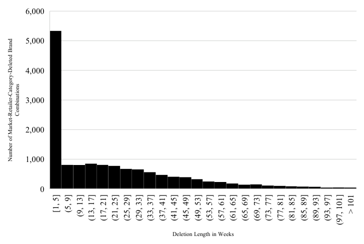

NOTE: figure/graphic rendered as an image from the PDF; its content is not machine-readable text. Caption (if any) follows as the next block.

**text found inside the figure**

[1, 5]

(5, 9]

(9, 13]

(13, 17]

(17, 21]

(21, 25]

(25, 29]

(29, 33]

(33, 37]

(37, 41]

(41, 45]

(45, 49]

(49, 53]

(53, 57]

(57, 61]

(61, 65]

(65, 69]

(69, 73]

(73, 77]

(77, 81]

(81, 85]

(85, 89]

(89, 93]

(93, 97]

(97, 101]

> 101

Number of Market-Retailer-Category-Deleted Brand

Combinations

0

1,000

2,000

3,000

4,000

5,000

6,000

Page 56

W5

**Table W1. Number of Observations, Means, and Standard Deviations by Competitor Brand Type and Marketing Mix**

#### **# Observations (at**

|  | theMarket - Retailer-Category- Brand -WeekLevel) | Weekly Revenue | PromotionPrice(Ratioof ActualtoRegularPricex 100) | FeatureAdvertising (WeightedPercentageacross SKUsandStores) | Regular Price($) | Line Length | Distributionin % |
| --- | --- | --- | --- | --- | --- | --- | --- |
| RivalNational |  | 320805 , . | 9559 . | 606 . | 847 . | 1141 . | 9871 . |
| Brands | 44753732 , , | (976000) , . | (688) . | (2013) . | (6251) . | (1346) . | (675) . |
| SisterBrands | 3767662 , , | 387162 , . | 9469 . | 726 . | 312 . | 1049 . | 9913 . |
|  |  | (899371) , . | (785) . | (2145) . | (1655) . | (955) . | (566) . |
| PrivateLabel | 7354915 , , | 576438 , . | 9612 . | 575 . | 206 . | 1661 . | 9957 . |
|  |  | (1894595) , . | (486) . | (1728) . | (618) . | (1713) . | (394) . |
| Overall | 55876309 , , | 358928 , . | 9560 . | 610 . | 727 . | 1203 . | 9885 . |
|  |  | (1139045) , . | (673) . | (1988) . | (5620) . | (1390) . | (639) . |

NOTE: table converted from PDF layout to HTML text; cell boundaries are reconstructed. See PDF if exact alignment matters.

Overall 55,876,309 3,589.28 95.60 6.10 7.27 12.03 98.85 (11,390.45) (6.73) (19.88) (56.20) (13.90) (6.39) Notes: Values represent averages, values in parentheses are standard deviations. Regular Price is not comparable across categories. To provide some insights into the relative price levels for the three brand types, we calculate for each of the 14,462 market-retailer-category-deleted brand combinations the regular price ratio of sister brands and private labels to the average rival national brand. On average, sister brands (private labels) have a 11% higher (14% lower) regular price than rival national brands.

Page 57

W6

#### **Web Appendix C: Correlation Matrix of Key Variables in Brand Revenue Model (Equation 1)**

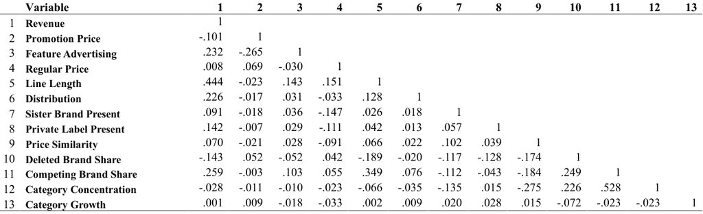

NOTE: complex table shown as an image of the PDF; the text below is a rough machine extraction and may be mis-aligned.

**extracted text (unreliable layout)**

; Variable ; 1 ; 2 ; 3 ; 4 ; 5 ; 6 ; 7 ; 8 ; 9 ; 10 ; 11 ; 12 ; 13 | 1 ; Revenue ; 1 ; ; ; ; ; ; ; ; ; ; ; ; | 2 ; PromotionPrice ; 101 -. ; 1 ; ; ; ; ; ; ; ; ; ; ; | 3 ; FeatureAdvertising ; 232 . ; 265 -. ; 1 ; ; ; ; ; ; ; ; ; ; | 4 ; RegularPrice ; 008 . ; 069 . ; 030 -. ; 1 ; ; ; ; ; ; ; ; ; | 5 ; LineLength ; 444 . ; 023 -. ; 143 . ; 151 . ; 1 ; ; ; ; ; ; ; ; | 6 ; Distribution ; 226 . ; 017 -. ; 031 . ; 033 -. ; 128 . ; 1 ; ; ; ; ; ; ; | 7 ; SisterBrandPresent ; 091 . ; 018 -. ; 036 . ; 147 -. ; 026 . ; 018 . ; 1 ; ; ; ; ; ; | 8 ; PrivateLabelPresent ; 142 . ; 007 -. ; 029 . ; 111 -. ; 042 . ; 013 . ; 057 . ; 1 ; ; ; ; ; | 9 ; PriceSimilarity ; 070 . ; 021 -. ; 028 . ; 091 -. ; 066 . ; 022 . ; 102 . ; 039 . ; 1 ; ; ; ; | 10 ; DeletedBrandShare ; 143 -. ; 052 . ; 052 -. ; 042 . ; 189 -. ; 020 -. ; 117 -. ; 128 -. ; 174 -. ; 1 ; ; ; | 11 ; CompetingBrandShare ; 259 . ; 003 -. ; 103 . ; 055 . ; 349 . ; 076 . ; 112 -. ; 043 -. ; 184 -. ; 249 . ; 1 ; ; | 12 ; CategoryConcentration ; 028 -. ; 011 -. ; 010 -. ; 023 -. ; 066 -. ; 035 -. ; 135 -. ; 015 . ; 275 -. ; 226 . ; 528 . ; 1 ; | 13 ; CategoryGrowth ; 001 . ; 009 . ; 018 -. ; 033 -. ; 002 . ; 009 . ; 020 . ; 028 . ; 015 . ; 072 -. ; 023 -. ; 023 -. ; 1

Page 58

W7

#### **Web Appendix D: Illustrative Data Structure of Treated and Control Cases**

In this illustrative example, we consider the deletion of brand D by retailer R in markets M1 and M2. Brand D is deleted in market M1 (M2) in week 53 (183). Market M2 serves as control unit for market M1; market M3 (to be deleted even later) serves as control unit for market M2. The data structure shows that while M2 serves as control unit (weeks 1 – 105), it is “never treated”. Table W2 and Figure W2 illustrate the data structure.

**Table W2. Illustrative Data Structure**

| "Case" | Deleted Brand | Competing Brand | Retailer | Market | Time | Treat |  | Post |  |
| --- | --- | --- | --- | --- | --- | --- | --- | --- | --- |
| 1 | D | C | R | M1 | 1 |  | 1 |  | 0 |
| 1 | D | C | R | M1 | 2 |  | 1 |  | 0 |
| 1 | D | C | R | M1 | … |  |  |  |  |
| 1 | D | C | R | M1 | 52 |  | 1 |  | 0 |
| 1 | D | C | R | M1 | 53 |  | 1 |  | 1 |
| 1 | D | C | R | M1 | 54 |  | 1 |  | 1 |
| 1 | D | C | R | M1 | … |  |  |  |  |
| 1 | D | C | R | M1 | 105 |  | 1 |  | 1 |
| 1 | D | C | R | M2 | 1 |  | 0 |  | 0 |
| 1 | D | C | R | M2 | 2 |  | 0 |  | 0 |
| 1 | D | C | R | M2 | … |  |  |  |  |
| 1 | D | C | R | M2 | 52 |  | 0 |  | 0 |
| 1 | D | C | R | M2 | 53 |  | 0 |  | 1 |
| 1 | D | C | R | M2 | 54 |  | 0 |  | 1 |
| 1 | D | C | R | M2 | … |  |  |  |  |
| 1 | D | C | R | M2 | 105 |  | 0 |  | 1 |
| 2 | D | C | R | M2 | 131 |  | 1 |  | 0 |
| 2 | D | C | R | M2 | 132 |  | 1 |  | 0 |
| 2 | D | C | R | M2 | … |  |  |  |  |
| 2 | D | C | R | M2 | 182 |  | 1 |  | 0 |
| 2 | D | C | R | M2 | 183 |  | 1 |  | 1 |
| 2 | D | C | R | M2 | 184 |  | 1 |  | 1 |
| 2 | D | C | R | M2 | … |  |  |  |  |
| 2 | D | C | R | M2 | 235 |  | 1 |  | 1 |
| 2 | D | C | R | M3 | 131 |  | 0 |  | 0 |
| 2 | D | C | R | M3 | 132 |  | 0 |  | 0 |
| 2 | D | C | R | M3 | … |  |  |  |  |
| 2 | D | C | R | M3 | 182 |  | 0 |  | 0 |
| 2 | D | C | R | M3 | 183 |  | 0 |  | 1 |
| 2 | D | C | R | M3 | 184 |  | 0 |  | 1 |
| 2 | D | C | R | M3 | … |  |  |  |  |
| 2 | D | C | R | M3 | 235 |  | 0 |  | 1 |

NOTE: table converted from PDF layout to HTML text; cell boundaries are reconstructed. See PDF if exact alignment matters.

Page 59

W8

**Figure W2. Visual Representation of Data Structure**

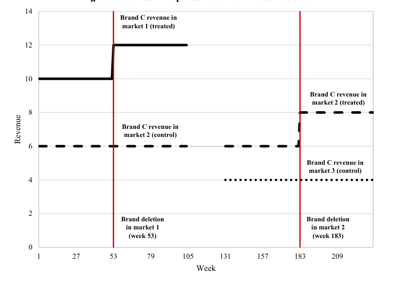

NOTE: figure/graphic rendered as an image from the PDF; its content is not machine-readable text. Caption (if any) follows as the next block.

**text found inside the figure**

0

10

20

30

40

50

60

70

80

90

100

0

2

4

6

8

10

12

14

1 27 53 79 105 131 157 183 209

Revenue

Week

**Brand C revenue in**

**market 1 (treated)**

**Brand C revenue in**

**market 2 (control)**

**Brand C revenue in**

**market 2 (treated)**

**Brand C revenue in**

**market 3 (control)**

**Brand deletion**

**in market 1**

**(week 53)**

**Brand deletion**

**in market 2**

**(week 183)**

Page 60

W9

#### **Web Appendix E: Evolution of Treated and Control Units**

**Figure W3. Pretreatment Evolution for Sample Case at 75<sup>th</sup> Percentile in Terms of Average Correlation (r = .903)**

#### **Revenue (r = .693) Promotion Price (r = .980) Feature Advertising (r = .999)**

**Regular Price (r = .967) Line Length (r = .928) Distribution (r = .908)**

Notes: Solid black lines show the treated unit, dotted black line the average control units.

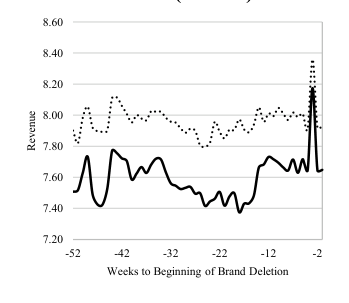

NOTE: figure/graphic rendered as an image from the PDF; its content is not machine-readable text. Caption (if any) follows as the next block.

**text found inside the figure**

7.20

7.40

7.60

7.80

8.00

8.20

8.40

8.60

-52 -42 -32 -22 -12 -2

Revenue

Weeks to Beginning of Brand Deletion

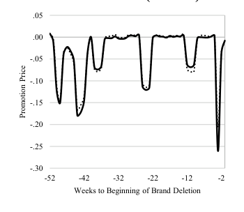

NOTE: figure/graphic rendered as an image from the PDF; its content is not machine-readable text. Caption (if any) follows as the next block.

**text found inside the figure**

-.30

-.25

-.20

-.15

-.10

-.05

.00

.05

-52 -42 -32 -22 -12 -2

Promotion Price

Weeks to Beginning of Brand Deletion

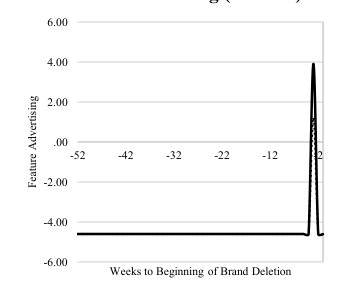

NOTE: figure/graphic rendered as an image from the PDF; its content is not machine-readable text. Caption (if any) follows as the next block.

**text found inside the figure**

-6.00

-4.00

-2.00

.00

2.00

4.00

6.00

-52 -42 -32 -22 -12 -2

Feature Advertising

Weeks to Beginning of Brand Deletion

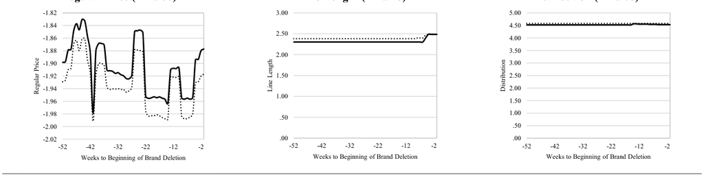

NOTE: figure/graphic rendered as an image from the PDF; its content is not machine-readable text. Caption (if any) follows as the next block.

**text found inside the figure**

-2.00

-1.98

-1.96

-1.94

-1.92

-1.90

-1.88

-1.86

-1.84

-1.82

-52 -42 -32 -22 -12 -2

Regular Price

Weeks to Beginning of Brand Deletion

.00

.50

1.00

1.50

2.00

2.50

3.00

-52 -42 -32 -22 -12 -2

Line Length

Weeks to Beginning of Brand Deletion

.50

1.00

1.50

2.00

2.50

3.00

3.50

4.00

4.50

5.00

-52 -42 -32 -22 -12 -2

Distribution

Weeks to Beginning of Brand Deletion

**Figure W4. Pretreatment Evolution for Sample Case at Median in Terms of Average Correlation (r = .868)**

#### **Revenue (r = .635) Promotion Price (r = .949) Feature Advertising (r = .999)**

**Regular Price (r = .824) Line Length (r = .950) Distribution (r = .886)**

Notes: Solid black lines show the treated unit, dotted black line the average control units.

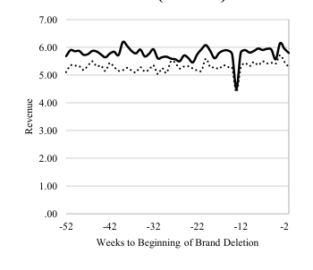

NOTE: figure/graphic rendered as an image from the PDF; its content is not machine-readable text. Caption (if any) follows as the next block.

**text found inside the figure**

.00

1.00

2.00

3.00

4.00

5.00

6.00

7.00

-52 -42 -32 -22 -12 -2

Revenue

Weeks to Beginning of Brand Deletion

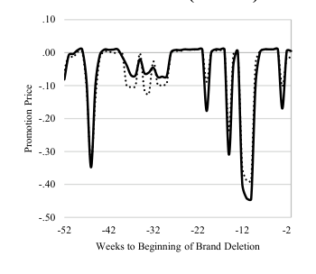

NOTE: figure/graphic rendered as an image from the PDF; its content is not machine-readable text. Caption (if any) follows as the next block.

**text found inside the figure**

-.50

-.40

-.30

-.20

-.10

.00

.10

-52 -42 -32 -22 -12 -2

Promotion Price

Weeks to Beginning of Brand Deletion

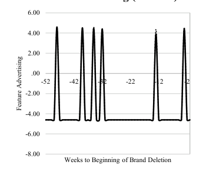

NOTE: figure/graphic rendered as an image from the PDF; its content is not machine-readable text. Caption (if any) follows as the next block.

**text found inside the figure**

-8.00

-6.00

-4.00

-2.00

.00

2.00

4.00

6.00

-52 -42 -32 -22 -12 -2

Feature Advertising

Weeks to Beginning of Brand Deletion

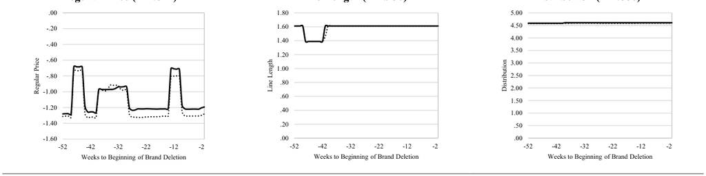

NOTE: figure/graphic rendered as an image from the PDF; its content is not machine-readable text. Caption (if any) follows as the next block.

**text found inside the figure**

-1.40

-1.20

-1.00

-.80

-.60

-.40

-.20

.00

-52 -42 -32 -22 -12 -2

Regular Price

Weeks to Beginning of Brand Deletion

.00

.20

.40

.60

.80

1.00

1.20

1.40

1.60

1.80

-52 -42 -32 -22 -12 -2

Line Length

Weeks to Beginning of Brand Deletion

.50

1.00

1.50

2.00

2.50

3.00

3.50

4.00

4.50

5.00

-52 -42 -32 -22 -12 -2

Distribution

Weeks to Beginning of Brand Deletion

**Figure W5. Pretreatment Evolution for Sample Case at 25<sup>th</sup> Percentile in Terms of Average Correlation (r = .840)**